# Deploying your App - Using Functions to Streamline Your Code - Shiny Modules

# Learning outcomes

These are the skills you’re supposed to walk away with:

- **Create strategies for analyzing text.**  
  You’re not just running code—you’re learning how to *think* about text data:
  - What questions to ask (e.g., “Which words are most common?”, “How does language differ between authors?”).
  - How to structure your workflow (cleaning, tokenizing, analyzing, visualizing).
- **Manipulate and analyze text data using `{tidytext}`.**  
  `{tidytext}` is an R package that turns text into “tidy” data: one token (usually a word) per row. That makes it easy to use with the rest of the tidyverse (`dplyr`, `ggplot2`, etc.). You’ll learn to:
  - Break text into words or n-grams.
  - Join with other data (like sentiment lexicons).
  - Summarize and visualize results.
- **Frequency analysis.**  
  This means counting how often words appear:
  - Which words are most common in a document or set of documents?
  - How does word frequency differ across authors, books, time periods, or categories?
  - Often the first step in understanding a text corpus.
- **Relationships among words.**  
  This is about how words appear *together*:
  - N-grams (e.g., “New York”, “data science”) to capture phrases.
  - Co-occurrence or correlation between words (which words tend to show up in the same context).
  - This helps reveal themes, topics, or stylistic patterns.
- **Sentiment analysis.**  
  You’ll learn to:
  - Use sentiment lexicons (lists of words labeled as positive, negative, anger, joy, etc.).
  - Join your text data with these lexicons.
  - Compute sentiment scores for documents, chapters, time periods, or categories.
  - Interpret how “emotional tone” changes across a text or between groups.
- **Build word cloud plots.**  
  Word clouds visualize word frequency by font size:
  - More frequent words appear larger.
  - It’s a quick, visual summary of what dominates the text.
  - You’ll likely use the `{wordcloud}` package for this.

# References and packages

The references list is basically your toolkit and background reading:

- **Text Mining with R (Silge & Robinson, 2025).**  
  This is the core book that your material is drawing from. It teaches text mining using tidy data principles and `{tidytext}`.
- **`{tidytext}` package (Silge & Robinson, 2016).**  
  The main R package for tidy text mining:
  - Functions like `unnest_tokens()` to turn text into tokens.
  - Built-in sentiment lexicons.
  - Tools for tf-idf, n-grams, etc.
- **`{stringi}` package (Gagolewski, 2026).**  
  A powerful string manipulation package:
  - Handling Unicode, pattern matching, text cleaning.
  - Often used behind the scenes or for more advanced text wrangling.
- **`{janeaustenr}` package (Silge, 2023).**  
  Provides the full text of Jane Austen’s novels:
  - Commonly used as example data for text mining.
  - Great for practicing on real literary text.
- **`{gutenbergr}` package (Robinson & Johnston, 2023).**  
  Interface to Project Gutenberg:
  - Lets you download public domain books easily.
  - Useful for building your own text corpora.
- **`{wordcloud}` package (Fellows, 2018).**  
  Used to create word cloud visualizations.
- **Other reference: `{scales}` (Wickham & Seidel, 2022).**  
  Helps with formatting axes, labels, and scales in plots—useful when visualizing text analysis results.

## What “Text Analysis with `{tidytext}`” means

The section “15.2 Text Analysis with `{tidytext}`” is telling you:

- **Source of material.**  
  Much of what you’ll see is adapted from *Text Mining with R* by Silge and Robinson. So you’re learning a well-established, widely used approach.
- **Definition of text mining.**  
  > “Text Mining can be considered as a process for extracting insights from text.”  
  That’s the core idea: you’re turning unstructured text (books, tweets, reviews, transcripts) into structured information you can analyze.
- **Historical context.**
  - Computer-based text mining dates back to:
    - The **1950s** with automated translation.
    - The **1940s** if you include code-breaking (e.g., WWII cryptanalysis).
  - This shows that using computers to work with language is not new—what’s new is the scale and sophistication.
- **CRAN Task View: NLP.**  
  There’s a curated list on CRAN of R packages for NLP:
  - Over 50 packages for gathering, organizing, modeling, and analyzing text.
  - `{tidytext}` is one piece of a larger ecosystem.

## How this fits into Natural Language Processing (NLP)

The text then zooms out: text mining is part of the broader field of NLP. It lists several major application areas:

- **Machine translation.**
  - Automatically translating text from one language to another (e.g., English → Spanish) without human intervention.
- **Speech recognition.**
  - Systems like Alexa, Google Assistant, Siri:
    - Convert spoken language to text.
    - Then interpret that text to figure out what you’re asking.
- **Sentiment analysis.**
  - Also called opinion mining or emotion AI.
  - Used to detect attitudes (positive/negative), emotions, or opinions in text:
    - Product reviews, tweets, survey responses, etc.
- **Question answering.**
  - Again, Alexa/Google/Siri:
    - Take a natural language question.
    - Retrieve or generate an answer in a way you can understand.
- **Automatic summarization.**
  - Reducing long documents into shorter summaries:
    - Extractive (pulling key sentences).
    - Abstractive (generating new text that captures the main ideas).
- **Chatbots.**
  - Often combine:
    - **Speech recognition** (or text input),
    - **Question answering**, and
    - Some memory/context within a specific domain (e.g., customer support, banking, tech help).
- **Market intelligence.**
  - Automated analysis of:
    - Searches, posts, tweets, reviews, etc.
  - Used to understand trends, brand perception, customer needs.
- **Text classification.**
  - Automatically assigning categories or tags to text:
    - Spam vs. not spam.
    - Topic labels (sports, politics, tech).
    - Relevance of reference material.
- **Character recognition.**
  - Optical Character Recognition (OCR):
    - Turning images of text (scans, photos) into machine-readable text.
- **Spelling and grammar checking.**
  - Tools that detect typos, grammar errors, and suggest corrections.

The key message: **text analysis/NLP is foundational for generative AI.**  
Generative AI (like large language models) relies on: - Massive amounts of text data. - Techniques from NLP (tokenization, embeddings, language modeling). - The same underlying idea: representing language in a way computers can work with.

## How all of this ties together for you

Putting it all together, this intro is saying:

1. **You’re learning a practical toolkit**:
   - `{tidytext}`, `{stringi}`, `{wordcloud}`, `{janeaustenr}`, `{gutenbergr}`, etc.
   - You’ll use them to clean, structure, and analyze text.
2. **You’ll practice core text mining tasks**:
   - Frequency analysis.
   - Relationships among words.
   - Sentiment analysis.
   - Visualizations like word clouds.
3. **You’re stepping into the broader world of NLP**:
   - The same ideas you use on small corpora in R scale up to real-world systems:
     - Search engines, chatbots, translation, generative AI.

## Ways to organize text for analysis

You’re being shown several common data structures for text. They all represent the same underlying thing—language—but in very different shapes.

### 1. Strings

- **What it is:**  
  Plain character data—just text stored as:
  - **Atomic vectors** (e.g., a character vector where each element is a document or a line), or
  - **Columns in a data frame/tibble**.
- **Pros:**
  - Simple, natural way to store text.
  - Good for reading, printing, and basic manipulation.
- **Cons:**
  - Hard to analyze directly.
  - You usually need to transform strings into something more structured (tokens, counts, etc.) before doing serious analysis.

### 2. Corpus

- **What it is:**  
  A **corpus** is a collection (library) of documents, where each document:
  - Contains the text (as a string).
  - Has **metadata**: author, title, date, source, language, etc.
- **Why it matters:**
  - Many NLP frameworks (like `tm`, `quanteda`) use corpus objects.
  - Metadata is crucial for grouping, comparing, and modeling (e.g., sentiment by author, topic by year).

### 3. Document–Term Matrix (DTM)

- **What it is:**  
  A matrix where:
  - **Rows = documents**
  - **Columns = terms (words or tokens)**
  - **Entries = some numeric value** for how strongly that term appears in that document.
- **Common values in the cells:**
  - **Raw counts:** how many times the word appears in the document.
  - **TF–IDF:**
    - **Term Frequency (TF):** how often a term appears in a document.
    - **Inverse Document Frequency (IDF):** downweights terms that appear in many documents (like “the”, “and”).
    - TF–IDF highlights words that are important for a specific document.
- **Sparse matrix:**
  - Most documents use only a small fraction of all possible words.
  - So most entries in the DTM are **0**.
  - To save memory and speed up computation, DTMs are usually stored as **sparse matrices** (only non-zero entries are stored).
- **Term–Document Matrix (TDM):**
  - Just the **transpose** of the DTM:
    - **Rows = terms**, **columns = documents**.
  - Same information, different orientation.

### Tidy text format (TTF)

Now we get to the main idea: **Tidy Text Format**.

#### What TTF is

- **Goal:**  
  Organize text so you can use the **tidyverse** (`dplyr`, `ggplot2`, etc.) easily.
- **Definition:**  
  A tidy text table (tibble/data frame) where:
  - Each row = **one token**.
  - Other columns = document ID, metadata, counts, etc.
- **Why this is powerful:**
  - You can use familiar verbs:
    - `filter()` to subset tokens.
    - `count()` to get frequencies.
    - `group_by()` to compare across documents, authors, time.
    - `inner_join()` to add sentiment labels or other lexicons.
  - It’s consistent with the broader tidy data philosophy:
    - Each variable is a column.
    - Each observation is a row.

#### What is a token?

- **Token:**  
  A “meaningful unit of text” that *you* decide based on your analysis.
- **Examples of tokens:**
  - **Word** (most common).
  - **N-gram:** sequence of ( n ) words (e.g., bigrams like “New York”, trigrams like “machine learning model”).
  - **Sentence.**
  - **Paragraph.**
  - **Larger units:** chapters, sections, even whole documents.
- **Key idea:**  
  You choose the token level that matches your question:
  - If you care about vocabulary: words.
  - If you care about phrases: n-grams.
  - If you care about narrative structure: sentences or paragraphs.

### Bag of words vs. more advanced representations

#### Bag of words

- **What it is:**  
  You treat a document as a “bag” of tokens:
  - You **ignore order**.
  - You **ignore syntax** (grammar, sentence structure).
  - You only care about **which tokens appear** and **how often**.
- **In practice:**
  - DTMs and TTF word counts are classic bag-of-words representations.
  - Great for:
    - Frequency analysis.
    - Basic classification.
    - Simple sentiment analysis.
- **Limitation:**
  - Loses context:
    - “not good” and “good” both contain “good”.
    - Word order, negation, sarcasm, and subtle meaning are not captured.

#### Neural word embeddings

- **Why they exist:**  
  To move beyond bag-of-words and capture **context** and **semantic relationships**.
- **What they do:**
  - Represent each word as a **vector of numbers** (an embedding).
  - These vectors are learned from large corpora so that:
    - Words used in similar contexts have similar vectors.
    - Relationships like “king – man + woman ≈ queen” can emerge.
- **Context sensitivity:**
  - Early embeddings (like Word2Vec) give **one vector per word**, regardless of context.
  - Newer models (like BERT) give **different vectors for the same word in different sentences**, capturing nuanced meaning.
- **Examples:**
  - **Word2Vec:**
    - Learns embeddings by predicting a word from its context (CBOW) or context from a word (Skip-gram).
  - **BERT (by Google):**
    - A transformer-based model.
    - Reads entire sentences bidirectionally.
    - Produces context-aware embeddings for each token.

So you can think of it like this: - **Bag of words:** counts, no order, no context. - **Embeddings:** numbers that encode meaning and context, learned from data.

### Language specifics and limitations

The text then zooms out to say: “We’re focusing on English, but the world is bigger.”

#### Why English first?

- **Reason:**
  - Many tools, examples, and packages are built around English.
  - English has relatively simple morphology (compared to some languages) and uses spaces between words, which makes tokenization easier.
- **Proto-Indo-European languages:**
  - Many European languages share structural similarities:
    - Word order, alphabet, word boundaries, etc.
  - Techniques used for English often transfer reasonably well to languages like Spanish, French, German, etc.—with adjustments.

#### Why other languages can be harder

- **Challenges:**
  - **No spaces between words** (e.g., Chinese, Japanese, Thai):
    - Tokenization itself becomes a non-trivial task.
  - **Rich morphology** (e.g., many forms of a word in Finnish, Turkish, some Indic languages):
    - Stemming/lemmatization is more complex.
  - **Different scripts** (e.g., Devanagari, Hangul, Arabic):
    - Requires Unicode-aware tools and language-specific rules.
- **Examples of language-specific tools:**
  - **Chinese:**
    - Specialized toolkits for Chinese NLP and speech processing in R.
  - **Indic languages (Hindi, Bengali, etc.):**
    - Indic NLP libraries (often in Python).
  - **Korean:**
    - `{KoNLP}` package in R.
  - **Multilingual NLP in R:**
    - `{udpipe}` supports many languages with pre-trained models.
- **Multilingual BERT:**
  - A version of BERT trained on many languages.
  - Helps bring powerful contextual embeddings to non-English text.
  - Still, performance varies by language and domain.

### How this all fits together in your workflow

If we connect the dots:

1. **Start with raw text**
   - Stored as strings in a data frame or as a corpus.
2. **Choose a representation:**
   - For tidyverse-style analysis: convert to **Tidy Text Format** (one token per row).
   - For machine learning models: maybe convert to a **DTM** or use **embeddings**.
3. **Decide your token:**
   - Words, n-grams, sentences, etc., depending on your question.
4. **Pick your level of sophistication:**
   - **Bag of words** for simple, interpretable analysis (counts, tf–idf, basic sentiment).
   - **Embeddings / BERT** for deeper, context-aware modeling.
5. **Remember language matters:**
   - English is the starting point here.
   - Other languages may need specialized tokenizers, models, and packages.

## General Concepts and Language Specifics in Text Analysis

### **Why the focus is on English**

English is the starting point for most introductory text‑analysis work because:

- It uses **spaces between words**, making tokenization straightforward.
- It has **relatively simple morphology** (few inflections compared to languages like Turkish or Finnish).
- Most NLP tools, datasets, and tutorials were historically developed for English first.

This makes English the easiest language for demonstrating foundational concepts such as tokenization, stemming, lemmatization, sentiment analysis, and bag‑of‑words modeling.

## How well do these techniques transfer to other languages?

Many European languages—especially those descended from **Proto‑Indo‑European** (e.g., Spanish, French, German, Italian)—share structural similarities with English:

- Alphabetic writing systems
- Word boundaries marked by spaces
- Similar grammatical categories

Because of this, **the same text‑analysis techniques often work with only minor adjustments**.

However, once you move beyond these languages, things get more complex.

## Why other languages can be more challenging

Languages differ dramatically in:

### 1. **Tokenization**

Some languages **do not use spaces** between words:

- Chinese
- Japanese
- Thai

Tokenization becomes a non‑trivial problem requiring specialized algorithms.

### 2. **Morphology**

Some languages have **rich inflectional systems**:

- Turkish
- Finnish
- Arabic
- Many Indic languages

A single root word may appear in dozens or hundreds of forms, making simple bag‑of‑words approaches less effective.

### 3. **Script and encoding**

Languages may use:

- Logographic scripts (Chinese)
- Abugidas (Hindi, Bengali)
- Syllabaries (Japanese kana)
- Alphabets with complex rules (Korean Hangul)

This requires Unicode‑aware processing and language‑specific tokenizers.

### 4. **Data availability**

Many languages are **low‑resource**, meaning:

- Few labeled datasets
- Limited pretrained models
- Sparse linguistic tools

This makes NLP tasks harder and less accurate.  
[Springer](https://link.springer.com/chapter/10.1007/978-3-031-88988-2_7)

### Tools for non‑English NLP

The text mentions several language‑specific toolkits:

#### **Chinese NLP**

- Specialized tokenizers and speech‑processing tools are required because Chinese lacks whitespace boundaries.

#### **Indic NLP (Python)**

- Handles languages like Hindi, Bengali, Tamil, etc.
- Deals with complex morphology and scripts.

#### **KoNLP (R)**

- Designed for Korean, which uses Hangul and has unique morphological rules.

#### **udpipe (R)**

- Supports many languages using pretrained models.
- Useful for tokenization, POS tagging, lemmatization, and dependency parsing.

These tools exist because **English‑centric NLP methods do not generalize cleanly** to all languages.

### Multilingual NLP and modern solutions

Modern NLP research is rapidly improving multilingual capabilities.

#### **Multilingual BERT (mBERT)**

- Trained on over 100 languages.
- Learns shared representations across languages.
- Helps with cross‑lingual tasks like translation, classification, and semantic similarity.  
  [shoutdigital.com](https://www.shoutdigital.com/insights/advancing-natural-language-processing-for-multilingual-interactions/)

#### **Cross‑lingual embeddings**

- Map words from different languages into a shared vector space.
- Allow models trained in English to transfer knowledge to other languages.  
  [deep-learning-mit.github.io](https://deep-learning-mit.github.io/staging/blog/2023/multilingual-representations-in-embeddings-models/)

#### Challenges remain

Even with multilingual models, issues persist:

- Low‑resource languages still lag behind.
- Morphological complexity reduces accuracy.
- Cultural and contextual differences affect sentiment and meaning.  
  [fastdatascience.com](https://fastdatascience.com/natural-language-processing/multilingual-natural-language-processing/)

## A Text Cleaning Workflow

### 1. Preserve the raw text unchanged

**Idea:** Treat raw text like raw data in any analysis—you never touch it.

- **Why keep an untouched copy?**
  - Cleaning is *destructive*: once you remove accents, punctuation, or words, you can’t always reconstruct the original.
  - If you discover a mistake or want to try a different cleaning strategy, you need the original to start over.
- **Practical habit:**
  - Store raw text in one object/column (e.g., `text_raw`).
  - Do all cleaning into a new object/column (e.g., `text_clean`).

This is about **reversibility and trust**—you always know you can go back.

### 2. Create a cleaned copy for analysis

**Idea:** All transformations happen on a *copy*, not the original.

- You might:
  - Lowercase text.
  - Standardize Unicode.
  - Normalize punctuation.
  - Remove or transform characters.
- Because it’s a copy, you’re free to experiment:
  - Try different tokenization strategies.
  - Compare results with and without transliteration.
  - Adjust stop-word lists.

This separation keeps your workflow **safe and flexible**.

### 3. Standardize Unicode representations

This is where things get subtle and “invisible.”

#### What is Unicode?

- Unicode is a **global standard** that assigns a unique code point to each character across languages and symbol systems.
- Example: the letter **“é”** can be represented in two ways:
  - **Precomposed (NFC):**
    - Single code point: `U+00E9` → “LATIN SMALL LETTER E WITH ACUTE”
  - **Decomposed (NFD):**
    - Two code points:
      - `U+0065` → “LATIN SMALL LETTER E”
      - `U+0301` → “COMBINING ACUTE ACCENT”
- Visually:
  - `é` (NFC)
  - `é` (NFD: `e` + combining accent)  
    They *look* identical, but they are **different sequences of characters**.

#### Why this is a problem

These invisible differences can break your analysis:

- **String matching fails:**
  - `"é" != "é"` if one is NFC and the other is NFD.
- **Tokenization issues:**
  - The same apparent word might be split or treated as different tokens.
- **Joins and comparisons break silently:**
  - Joining on text columns may miss matches that *look* identical.

### What standardization does

- Standardization converts all text to a **single, consistent Unicode normalization form**.
- Common choice: **NFC** (Canonical Composition).
  - Accented characters are stored as single units.
  - Works well with word-level tokenization and most tools. [RDocumentation](https://www.rdocumentation.org/packages/stringi/versions/1.8.7/topics/stri_trans_nfc) [stringi](https://stringi.gagolewski.com/rapi/stri_trans_nf.html)

#### In R with `{stringi}`

You might do:

```r
text_nfc <- stringi::stri_trans_nfc(text_raw)
```

This:

- Converts all strings to NFC.
- Removes hidden encoding differences.
- Makes later steps (matching, tokenizing, joining) more reliable.

**Key distinction:**  
- **Standardization (Step 3)**: fixes *hidden encoding differences* without changing what the text *looks like*.

### 4. Normalize and simplify the text (as appropriate)

Once Unicode is standardized, the text is internally consistent—but still stylistically varied.

#### What normalization is

Normalization is a **deliberate simplification** of text to reduce variation that can interfere with analysis.

Examples:

- **Punctuation and symbols:**
  - Em dash `—` → hyphen `-`
  - Curly quotes `“ ”` → straight quotes `"`
  - Curly apostrophe `’` → straight apostrophe `'`
- **Accents (via transliteration):**
  - “café” → “cafe”
  - “naïve” → “naive”

This helps:

- Improve tokenization.
- Reduce duplicate tokens that differ only by style.
- Make matching and aggregation more robust.

#### But normalization can change meaning

Unlike Unicode standardization, normalization can **alter the text**:

- Removing punctuation may remove clues about structure or emphasis.
- Transliteration may collapse distinct words into the same form.

So normalization is **context-dependent**: - Great for frequency counts, rough clustering, or search. - Risky when exact spelling or nuance matters (e.g., legal text, names, linguistic research).

### 5. Transliteration and meaning

Transliteration is a specific kind of normalization: mapping characters to simpler equivalents, often ASCII.

#### Examples

- “café” → “cafe”
- “naïve” → “naive”

Helpful for:

- Simplifying matching and counting.
- Handling systems that only support ASCII.
- Reducing noise from minor spelling variations.

But it can **change semantics**:

- “résumé” → “resume”
  - *résumé*: document summarizing experience.
  - *resume*: to continue after a pause.
- “exposé” → “expose”
  - *exposé*: a revealing report.
  - *expose*: the verb “to reveal”.

So:

- **Good for:** exploratory analysis, word frequency, rough clustering.
- **Bad for:** tasks where spelling distinctions matter (e.g., named entities, legal terms, linguistic nuance).

### 6. Example: Standardization and normalization with `{stringi}`

You’re given this example:

```r
library(stringi)

text_raw <- c("café — “quoted text”", "caché isn’t the same as cache")

# Step 3: Standardize Unicode (NFC)
text_nfc <- stringi::stri_trans_nfc(text_raw)

# Step 4: Normalize punctuation and optionally transliterate
text_clean <- text_nfc |>
  stringi::stri_replace_all_fixed("—", "-") |>     # em dash → hyphen
  stringi::stri_replace_all_fixed("“", "\"") |>    # left quote → "
  stringi::stri_replace_all_fixed("”", "\"") |>    # right quote → "
  stringi::stri_replace_all_fixed("’", "'") |>     # curly apostrophe → '
  stringi::stri_trans_general("Latin-ASCII")       # transliteration

text_raw
```

```
[1] "café — “quoted text”"          "caché isn’t the same as cache"
```

```r
# [1] "café — “quoted text”"          "caché isn’t the same as cache"

text_clean
```

```
[1] "cafe - \"quoted text\""        "cache isn't the same as cache"
```

```r
# [1] "cafe - \"quoted text\""        "cache isn't the same as cache"
```

What happened?

- **Standardization (NFC):**
  - Ensures all characters like “é” are in a consistent internal form.
- **Normalization:**
  - `—` → `-`
  - `“` and `”` → `"`
  - `’` → `'`
  - Accented characters → ASCII equivalents (`"café"` → `"cafe"`, `"caché"` → `"cache"`)

Notice the semantic issue:

- `"caché isn’t the same as cache"`  
  becomes
- `"cache isn't the same as cache"`

Now the sentence is **logically false** and loses its original point. That’s the cost of transliteration.

This is a perfect illustration of why you must **choose normalization steps intentionally**.

### 7. Tokenize the text

Once text is standardized and normalized (as needed), you **tokenize** it.

- **Tokenization:** splitting text into meaningful units:
  - Words
  - N-grams (e.g., bigrams, trigrams)
  - Sentences
  - Paragraphs
- **Choice depends on your goal:**
  - Word frequency → word tokens.
  - Phrase analysis → n-grams.
  - Sentiment over narrative flow → sentences or paragraphs.

In `{tidytext}`, this is often done with `unnest_tokens()`.

### 8. Remove or customize stop words

**Stop words:** very common words like “the”, “and”, “is”.

- Often removed to:
  - Focus on content words.
  - Reduce noise in frequency analysis or topic modeling.
- But they’re not always “junk”:
  - In sentiment analysis, words like “not” are crucial.
  - In phrase detection, function words can matter.

So you might:

- Start with a standard stop-word list.
- Customize it:
  - Remove “not” from the stop list.
  - Add domain-specific words (e.g., “http”, “www”, “rt” in tweets).

Stop-word handling is **not one-size-fits-all**—it’s part of your modeling choices.

### 9. Document every cleaning choice

This is the part most people skip—and regret later.

- **Why document?**
  - Every cleaning step changes the data.
  - Different choices (e.g., transliteration vs. not, stop words vs. none) can lead to different conclusions.
  - Reproducibility: you (or someone else) should be able to rerun the analysis and get the same results.

Good practice:

- Keep your cleaning steps in a script, in order.
- Comment *why* you made each decision.
- Note especially:
  - Whether you transliterated.
  - Which stop-word list you used.
  - How you tokenized.

### 10. How this all fits into the bigger workflow

Putting it together, your text cleaning pipeline looks like:

1. **Keep raw text unchanged.**
2. **Create a working copy for cleaning.**
3. **Standardize Unicode** (e.g., NFC) to remove hidden encoding differences.
4. **Normalize text** (punctuation, quotes, dashes, optional transliteration) based on your goals.
5. **Tokenize** into words, n-grams, sentences, etc.
6. **Handle stop words** (remove, customize, or keep).
7. **Document every step** for transparency and reproducibility.

Then, with `{tidytext}`, `{stringr}`, and `{stringi}`, you move from messy raw text to **structured, analyzable data**—ready for frequency analysis, sentiment, modeling, and visualization.

## The {tidytext} package

### 1. What `{tidytext}` is for

**`{tidytext}`** is an R package that:

- **Turns text into tidy data** (one token per row). [juliasilge.github.io](https://juliasilge.github.io/tidytext/) [Text Mining with R](https://www.tidytextmining.com/tidytext.html)
- Plays nicely with **`{dplyr}`**, **`{ggplot2}`**, and the rest of the tidyverse.
- Gives you tools for:
  - Tokenization (`unnest_tokens()`).
  - Sentiment analysis.
  - Working with stop words and lexicons.

You load it like this:

```r
library(tidyverse)
library(tidytext)
```

### 2. Starting point: a character vector of lines

You’re given the first stanza of Pablo Neruda’s *If You Forget Me* as a **character vector**:

```r
text <- c(
  "If You Forget Me",
  "by Pablo Neruda",
  "I want you to know",
  "one thing.",
  "You know how this is:",
  "if I look",
  "at the crystal moon, at the red branch",
  "of the slow autumn at my window,",
  "if I touch",
  "near the fire",
  "the impalpable ash",
  "or the wrinkled body of the log,",
  "everything carries me to you,",
  "as if everything that exists,",
  "aromas, light, metals,",
  "were little boats",
  "that sail",
  "toward those isles of yours that wait for me."
)
```

This is:

- A **vector of length 18** (18 lines).
- Each element is a **line of text**, not yet in tidy format.

### 3. Quick exploration with `length()`, `map_dbl()`, `str_length()`, `str_count()`

You’re asked to get some basic info:

#### 3.1 Number of lines

```r
length(text)
```

```
[1] 18
```

- Returns `18` → 18 lines.

#### 3.2 Number of characters per line

```r
map_dbl(text, str_length)
```

```
 [1] 16 15 18 10 21  9 38 32 10 13 18 32 29 29 22 17  9 45
```

- `str_length()` (from `{stringr}`) counts characters in each string.
- `map_dbl()` (from `{purrr}`) applies `str_length()` to each element and returns a numeric vector.
- You get a sense of line length variation.

#### 3.3 Number of words per line

```r
map_dbl(text, ~ str_count(., "\\w+"))
```

```
 [1] 4 3 5 2 5 3 8 7 3 3 3 7 5 5 3 3 2 9
```

- `str_count(., "\\w+")` counts word-like sequences (letters/digits/underscore).
- `~` defines an anonymous function; `.` is the current element.
- This gives you **words per line**.

#### 3.4 Total number of words

```r
sum(map_dbl(text, ~ str_count(., "\\w+")))
```

```
[1] 80
```

- Sums all word counts across lines.
- You’re told the result is **80 words**.

So at this point you know:

- 18 lines.
- 80 words total.
- But this is still just a **character vector**, not a tibble, and definitely not one-token-per-row.

### 4. Why this is “not tidy text format”

Tidy text format means:

- **One token per row**.
- Stored in a **tibble/data frame**.
- With other columns for metadata (e.g., line number, document ID).

Right now:

- You have a **vector**, not a tibble.
- Each element is a **whole line**, not individual tokens.
- So you can’t easily:
  - Join with sentiment lexicons.
  - Count words with `count(word, ...)`.
  - Group by line or other metadata.

You need to **wrap this vector in a tibble** and then **tokenize**.

### 5. Step 1: Convert the vector to a tibble with an index

You create a tibble with:

- A **line number** column.
- A **text** column.

```r
text_df <- tibble(
  line = seq_len(length(text)),
  text = text
)
head(text_df, 10)
```

```
# A tibble: 10 × 2
    line text
   <int> <chr>
 1     1 If You Forget Me
 2     2 by Pablo Neruda
 3     3 I want you to know
 4     4 one thing.
 5     5 You know how this is:
 6     6 if I look
 7     7 at the crystal moon, at the red branch
 8     8 of the slow autumn at my window,
 9     9 if I touch
10    10 near the fire
```

This gives something like:

| line | text |
| --- | --- |
| 1 | “If You Forget Me” |
| 2 | “by Pablo Neruda” |
| 3 | “I want you to know” |
| … | … |

Why this matters:

- **`line`** preserves the original structure (which line each token came from).
- This is a common pattern: add an index (line, sentence, document ID) so you can group or reconstruct later.

### 6. Step 2: Convert to tidy text with `unnest_tokens()`

Now you use `unnest_tokens()` from `{tidytext}` to go from:

- One row per **line** → one row per **token**.

#### 6.1 Basic usage

```r
text_df |>
  unnest_tokens(
    output = word,
    input  = text
  ) |>
  head(10)
```

```
# A tibble: 10 × 2
    line word
   <int> <chr>
 1     1 if
 2     1 you
 3     1 forget
 4     1 me
 5     2 by
 6     2 pablo
 7     2 neruda
 8     3 i
 9     3 want
10     3 you
```

Key arguments:

- **`tbl`**: the input tibble (`text_df`), usually passed via the pipe.
- **`output`**: name of the new column that will hold tokens (here, `word`).
- **`input`**: the column containing the original text (here, `text`).
- **`token`** (optional): what kind of token to create; default is `"words"`.

Under the hood:

- Each row’s `text` is split into words.
- Each word becomes its **own row**.
- The `line` column is **repeated** for each word from that line.

Result:

- You now have **80 rows** (one per word).
- Columns: `line`, `word`.

#### 6.2 Token types

`unnest_tokens()` supports many token types via `token =`:

- **`"words"`** (default)
- `"characters"`
- `"ngrams"` (e.g., bigrams, trigrams)
- `"sentences"`
- `"lines"`
- `"paragraphs"`
- `"regex"` (custom splitting)
- `"tweets"` (preserves usernames, hashtags, URLs)
- `"ptb"` (Penn Treebank tokenization)

This is how you control the **granularity** of your analysis.

#### 6.3 Defaults: lowercase and punctuation

By default, `unnest_tokens()`:

- **Strips punctuation**.
- **Converts to lowercase**.

So:

- `"You know how this is:"`  
  becomes tokens like `"you"`, `"know"`, `"how"`, `"this"`, `"is"`.

If you want to **keep case**, use:

```r
text_df |>
  unnest_tokens(
    output = word,
    input  = text,
    to_lower = FALSE
  )
```

```
# A tibble: 80 × 2
    line word
   <int> <chr>
 1     1 If
 2     1 You
 3     1 Forget
 4     1 Me
 5     2 by
 6     2 Pablo
 7     2 Neruda
 8     3 I
 9     3 want
10     3 you
# ℹ 70 more rows
```

### 7. Step 3: Remove stop words with `anti_join(stop_words)`

Now you have 80 word tokens, but many are **very common words**:

- “I”, “the”, “and”, “or”, “if”, “you”, etc.

These are **stop words**—often not useful for certain analyses (like topic modeling or simple frequency analysis).

#### 7.1 Load built-in stop words

`{tidytext}` includes a data frame called `stop_words`:

```r
data(stop_words)
```

- Contains **1,149 stop words** from three lexicons. [juliasilge.github.io](https://juliasilge.github.io/tidytext/) [The Comprehensive R Archive Network](https://cran.r-project.org/web/packages/tidytext/vignettes/tidytext.html)
- Column `word` holds the stop word itself.

#### 7.2 Remove stop words with `anti_join()`

You:

```r
text_df |>
  unnest_tokens(word, text) |>
  anti_join(stop_words, by = "word") |>  # remove rows whose 'word' is in stop_words
  count(word, sort = TRUE) ->            # count remaining words
  text_word_count
```

What happens:

1. **`unnest_tokens(word, text)`**
   - One row per word, 80 rows total.
2. **`anti_join(stop_words, by = "word")`**
   - Keeps only rows where `word` is **not** in `stop_words$word`.
   - This is a **filtering join**: it removes “uninteresting” common words.
3. **`count(word, sort = TRUE)`**
   - Groups by `word` and counts occurrences.
   - Sorts by frequency (most common first).
   - Result is a tibble with columns: `word`, `n`.
4. **Assignment to `text_word_count`**
   - Stores the result for later use.

#### 7.3 How many words are left?

```r
nrow(text_word_count)
```

```
[1] 26
```

- You’re told: **26 rows instead of 80**.
- That means:
  - 80 total tokens.
  - After removing stop words and collapsing duplicates via `count()`, you have 26 **unique, non-stop words**.

These are the words that carry more **semantic weight** in this stanza.

### 8. The core workflow you just practiced

You’ve basically walked through the minimal tidy text pipeline:

1. **Convert raw text to a tibble**
   - One row per unit (line, document, etc.).
   - Add an index column (`line`) to preserve structure.
2. **Convert to tidy text format with `unnest_tokens()`**
   - One row per token (usually word).
   - Keep metadata columns (like `line`) alongside tokens.
3. **Remove stop words (if appropriate)**
   - Use `stop_words` and `anti_join()` to filter out very common words.
   - This sharpens your focus on content-bearing terms.
4. **Summarize**
   - Use `count(word, sort = TRUE)` to see which words dominate.
5. **Save to a new tibble**
   - `text_word_count` is now your cleaned, token-level data ready for:
     - Frequency plots.
     - Word clouds.
     - Further analysis (e.g., sentiment, n-grams).

## **Tidytext Example 2: Jane Austen’s Novels with `{janeaustenr}`**

This example scales up from a small poem to a **full literary corpus**—all six major Jane Austen novels. It shows how tidy text methods handle large, structured text.

The `{janeaustenr}` package provides:

- Clean, pre‑processed text from Project Gutenberg
- A consistent format across books
- Metadata (book titles)

This makes it perfect for learning text mining without worrying about messy raw data.

### Load the data

```r
library(janeaustenr)
```

The function:

```r
austen_books()
```

```
# A tibble: 73,422 × 2
   text                    book
 * <chr>                   <fct>
 1 "SENSE AND SENSIBILITY" Sense & Sensibility
 2 ""                      Sense & Sensibility
 3 "by Jane Austen"        Sense & Sensibility
 4 ""                      Sense & Sensibility
 5 "(1811)"                Sense & Sensibility
 6 ""                      Sense & Sensibility
 7 ""                      Sense & Sensibility
 8 ""                      Sense & Sensibility
 9 ""                      Sense & Sensibility
10 "CHAPTER 1"             Sense & Sensibility
# ℹ 73,412 more rows
```

returns a tibble with:

| column | meaning |
| --- | --- |
| **text** | Lines of text (≈70 characters each) |
| **book** | Factor indicating which novel the line belongs to |

This is your **corpus**.

### Inspect how chapters are marked

Before adding metadata, you need to understand how chapters appear in the text.

```r
austen_books() |> head(20)
```

```
# A tibble: 20 × 2
   text                                                                    book
   <chr>                                                                   <fct>
 1 "SENSE AND SENSIBILITY"                                                 Sens…
 2 ""                                                                      Sens…
 3 "by Jane Austen"                                                        Sens…
 4 ""                                                                      Sens…
 5 "(1811)"                                                                Sens…
 6 ""                                                                      Sens…
 7 ""                                                                      Sens…
 8 ""                                                                      Sens…
 9 ""                                                                      Sens…
10 "CHAPTER 1"                                                             Sens…
11 ""                                                                      Sens…
12 ""                                                                      Sens…
13 "The family of Dashwood had long been settled in Sussex.  Their estate" Sens…
14 "was large, and their residence was at Norland Park, in the centre of"  Sens…
15 "their property, where, for many generations, they had lived in so"     Sens…
16 "respectable a manner as to engage the general good opinion of their"   Sens…
17 "surrounding acquaintance.  The late owner of this estate was a single" Sens…
18 "man, who lived to a very advanced age, and who for many years of his"  Sens…
19 "life, had a constant companion and housekeeper in his sister.  But he… Sens…
20 "death, which happened ten years before his own, produced a great"      Sens…
```

Then search for lines that begin with “chapter”:

```r
austen_books() |>
  filter(str_detect(text, "(?i)^chapter")) |>
  slice_sample(n = 10)
```

```
# A tibble: 10 × 2
   text          book
   <chr>         <fct>
 1 CHAPTER XXXIV Mansfield Park
 2 CHAPTER 4     Northanger Abbey
 3 CHAPTER VII   Mansfield Park
 4 CHAPTER XXI   Mansfield Park
 5 Chapter 14    Persuasion
 6 CHAPTER IV    Emma
 7 Chapter 8     Pride & Prejudice
 8 CHAPTER 41    Sense & Sensibility
 9 CHAPTER III   Emma
10 CHAPTER IX    Emma
```

#### What you learn:

- Chapters always begin with the word **chapter**
- Case may vary: *CHAPTER*, *Chapter*, *chapter*
- Numbers may be **Arabic** (e.g., “1”) or **Roman numerals** (e.g., “XIV”)

This lets you build a **chapter counter**.

### Add metadata: book, chapter, line number

This is a crucial step. You’re preparing the text so that after tokenization you can still:

- Reconstruct where each word came from
- Analyze by book
- Analyze by chapter
- Analyze by line

#### Code:

```r
austen_books() |>
  group_by(book) |>
  mutate(
    linenumber = row_number(),
    chapter = cumsum(str_detect(
      text,
      regex("^chapter [\\divxlc]", ignore_case = TRUE)
    )),
    .before = text
  ) |>
  ungroup() |>
  select(book, chapter, linenumber, text) ->
orig_books
```

#### What each part does:

##### `group_by(book)`

Ensures line numbers and chapter counts restart for each novel.

##### `linenumber = row_number()`

Adds a sequential line index within each book.

##### `chapter = cumsum(str_detect(...))`

- `str_detect()` returns TRUE when a line starts with “chapter …”
- `cumsum()` turns TRUE/FALSE into a running chapter count  
  (each TRUE increments the chapter number)

##### `regex(..., ignore_case = TRUE)`

Makes the pattern case‑insensitive.

##### `.before = text`

Places the new columns before the text column.

##### `ungroup()`

Removes grouping so later operations don’t accidentally group by book.

##### `select(book, chapter, linenumber, text)`

Keeps only the relevant columns.

#### Result:

- **73,422 lines**
- **~730,000 total words** (non‑unique)

This is your **structured corpus**.

### Convert to tidy text format

Now you tokenize the text into **one word per row**.

```r
orig_books |>
  unnest_tokens(word, text) |>   # ~725,055 rows
  mutate(word = str_extract(word, "[a-z']+")) |>
  anti_join(stop_words, by = "word") ->
tidy_books
```

Let’s break this down.

#### Step A: `unnest_tokens(word, text)`

This:

- Splits each line into words
- Removes punctuation
- Converts to lowercase
- Produces **one row per word**
- Keeps metadata columns (`book`, `chapter`, `linenumber`)

You now have **725,055 rows**—one per token.

#### Step B: Clean formatting characters

Project Gutenberg uses underscores to mark italics:

- `_happy_`
- `_very_important_`

`str_extract(word, "[a-z']+")` pulls out only:

- lowercase letters
- apostrophes

So `_happy_` → `happy`

#### Step C: Remove stop words

```r
anti_join(stop_words, by = "word")
```

This removes extremely common words like:

- the
- and
- of
- to
- I

These words dominate frequency counts but rarely add meaning.

### Inspect the cleaned tidy text

#### Number of rows:

```r
nrow(tidy_books)
```

```
[1] 216385
```

Result:

- **216,385 tokens**  
  (after removing stop words and formatting)

#### Number of unique words:

```r
length(unique(tidy_books$word))
```

```
[1] 13464
```

Result:

- **13,464 unique words**

This is your **vocabulary**.

### Count word frequencies

```r
tidy_books |>
  count(word, sort = TRUE)
```

```
# A tibble: 13,464 × 2
   word       n
   <chr>  <int>
 1 miss    1860
 2 time    1339
 3 fanny    862
 4 dear     822
 5 lady     819
 6 sir      807
 7 day      797
 8 emma     787
 9 sister   727
10 house    699
# ℹ 13,454 more rows
```

This gives:

- Each unique word
- How many times it appears across all six novels
- Sorted from most to least frequent

This is the foundation for:

- Word clouds
- Zipf’s law analysis
- TF‑IDF
- Topic modeling
- Sentiment analysis

### Plot the most common words

#### Basic plot (words with > 500 occurrences)

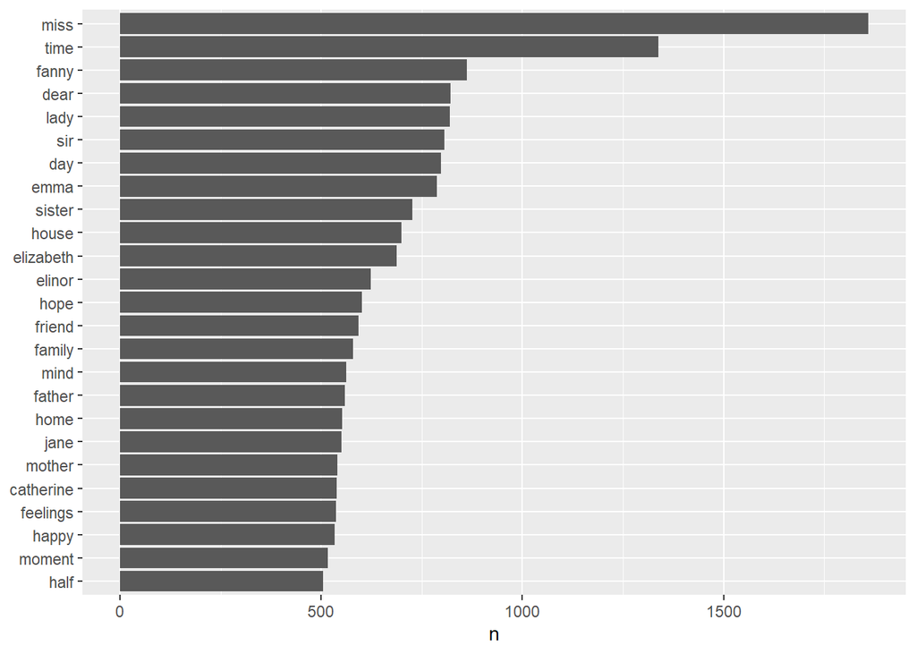

```r
tidy_books |>
  count(word, sort = TRUE) |>
  filter(n > 500) |>
  mutate(word = fct_reorder(word, n)) |>
  ggplot(aes(word, n)) +
  geom_col() +
  xlab(NULL) +
  coord_flip()
```

# Example

## *Part I — Plot the Most Common Words**

## **Problem (Part I)**

Using the tidy version of Jane Austen’s novels (`tidy_books`), plot the **most common words** (defined as words appearing more than 500 times) in **descending order**, using a simple bar chart.

## *Solution (Part I)**

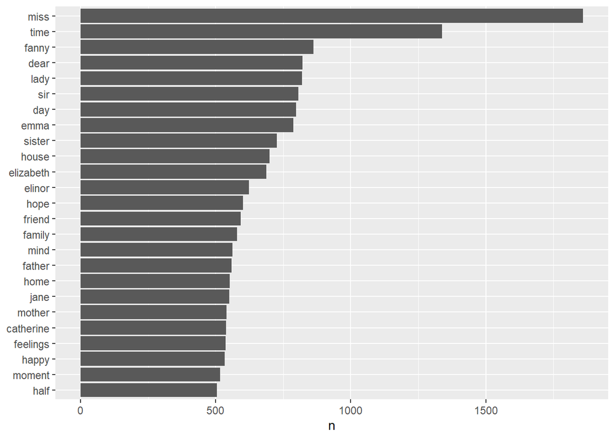

```r
tidy_books |>
  count(word, sort = TRUE) |>
  filter(n > 500) |>
  mutate(word = fct_reorder(word, n)) |>
  ggplot(aes(word, n)) +
  geom_col() +
  xlab(NULL) +
  coord_flip()
```

## **Explanation (Part I)**

### **1. Count words**

```r
count(word, sort = TRUE)
```

Creates a frequency table of all words across all six novels.

### **2. Filter to “most common”**

```r
filter(n > 500)
```

Keeps only words appearing more than 500 times.

### **3. Reorder factor levels**

```r
mutate(word = fct_reorder(word, n))
```

Ensures the bars appear in descending order.

### **4. Plot**

- `geom_col()` makes a bar chart
- `coord_flip()` rotates it horizontally for readability

This gives a clean visualization of Austen’s most frequent words.

### **What you’ve accomplished**

You’ve now seen the full tidy‑text workflow applied to a **large literary corpus**:

#### Add metadata (book, chapter, line)

#### Tokenize into words

####Clean formatting  
#### Remove stop words  
#### Count frequencies  
#### Visualize results

This is the exact same workflow used for:

- Social media analysis
- Customer reviews
- News articles
- Scientific papers
- Chat logs
- Historical documents

Once you understand this pattern, you can analyze *any* text dataset.

## Part II — Words Unique to Each Book**

## **Problem (Part II)**

Find the words that:

1. Occur in **only one** of Jane Austen’s books
2. And within each book, find the **most frequent** such word

You are encouraged to use:

- `pivot_wider()`
- `pivot_longer()`
- `across()`
- `c_across()`
- The magrittr pipe (`%>%` or `|>`)

## **Solution (Part II)**

```r
tidy_books |>
  group_by(book) |>
  count(word, sort = TRUE) |>
  ungroup() |>
  pivot_wider(names_from = book, values_from = n) |>
  mutate(across(where(is.numeric), is.na, .names = "na_{ .col}")) |>
  rowwise() |>
  mutate(tot_books = sum(c_across(starts_with("na")))) |>
  ungroup() |>
  filter(tot_books == max(tot_books)) |>
  select(!(starts_with("na_") | starts_with("tot"))) |>
  pivot_longer(-word,
    names_to = "book", values_to = "count",
    values_drop_na = TRUE
  ) |>
  group_by(book) |>
  filter(count == max(count)) |>
  arrange(desc(count))
```

```
# A tibble: 6 × 3
# Groups:   book [6]
  word     book                count
  <chr>    <chr>               <int>
1 elinor   Sense & Sensibility   623
2 crawford Mansfield Park        493
3 weston   Emma                  389
4 darcy    Pride & Prejudice     374
5 elliot   Persuasion            254
6 tilney   Northanger Abbey      196
```

## **Explanation (Part II)**

### **1. Count words within each book**

```r
group_by(book) |> count(word)
```

Creates a table of word frequencies per book.

### **2. Pivot wider**

```r
pivot_wider(names_from = book, values_from = n)
```

Creates a structure like:

| word | Emma | Persuasion | MansfieldPark | … |
| --- | --- | --- | --- | --- |

Words missing from a book become `NA`.

### **3. Detect which books a word does *not* appear in**

```r
mutate(across(where(is.numeric), is.na, .names = "na_{.col}"))
```

Creates TRUE/FALSE columns:

- `na_Emma`
- `na_Persuasion`
- …

TRUE = word does **not** appear in that book.

### **4. Count how many books the word is missing from**

```r
rowwise() |> mutate(tot_books = sum(c_across(starts_with("na"))))
```

If there are 6 books:

- A word appearing in **only one** book → `tot_books = 5`
- A word appearing in **all** books → `tot_books = 0`

### **5. Filter to words appearing in only one book**

```r
filter(tot_books == max(tot_books))
```

### **6. Remove helper columns**

```r
select(!(starts_with("na_") | starts_with("tot")))
```

### **7. Pivot back to long format**

```r
pivot_longer(-word, names_to = "book", values_to = "count", values_drop_na = TRUE)
```

Now you have:

word | book | count |

Only for the book where the word appears.

### **8. For each book, keep the most frequent unique word**

```r
group_by(book) |> filter(count == max(count))
```

This gives the **top unique word** for each novel.

## **Part III — What if You Don’t Know How Many Books There Are?**

## **Problem (Part III)**

Modify your approach so it works even if:

- You don’t know how many books there are
- Or there are many books
- Or the book names are unknown

## **Good news:**

The solution from Part II **already works for any number of books**.

Why?

- `pivot_wider()` automatically creates one column per book
- `across(where(is.numeric))` automatically selects all book columns
- `starts_with("na_")` automatically finds all NA‑indicator columns
- `pivot_longer()` automatically returns to tidy format

So the solution for Part III is **identical**:

### **Solution (Part III)**

*(same as Part II)*

```r
tidy_books |>
  group_by(book) |>
  count(word, sort = TRUE) |>
  ungroup() |>
  pivot_wider(names_from = book, values_from = n) |>
  mutate(across(where(is.numeric), is.na, .names = "na_{ .col}")) |>
  rowwise() |>
  mutate(tot_books = sum(c_across(starts_with("na")))) |>
  ungroup() |>
  filter(tot_books == max(tot_books)) |>
  select(!(starts_with("na_") | starts_with("tot"))) |>
  pivot_longer(-word,
    names_to = "book", values_to = "count",
    values_drop_na = TRUE
  ) |>
  group_by(book) |>
  filter(count == max(count)) |>
  arrange(desc(count))
```

```
# A tibble: 6 × 3
# Groups:   book [6]
  word     book                count
  <chr>    <chr>               <int>
1 elinor   Sense & Sensibility   623
2 crawford Mansfield Park        493
3 weston   Emma                  389
4 darcy    Pride & Prejudice     374
5 elliot   Persuasion            254
6 tilney   Northanger Abbey      196
```

### **Summary of All Parts**

| Part | Task | Key Skills |
| --- | --- | --- |
| **I** | Plot most common words | `count()`, `filter()`, `ggplot()`, `fct_reorder()` |
| **II** | Find words unique to each book | `pivot_wider()`, `across()`, `c_across()`, `pivot_longer()` |
| **III** | Make solution scalable to unknown number of books | Dynamic column selection, no hard‑coding |

Below is a *structured* Compare Frequencies Across Authors* task.

1. **The problem**
2. **A clean, reproducible workflow**
3. **Full code for each step**
4. **Why each step matters**
5. **How to interpret the final plots and correlations**

This is designed to match the style of the earlier Parts I–III solutions.

### **Compare Word Frequencies Across Authors**

We want to compare **Jane Austen** to:

- **The Brontë Sisters** (Charlotte, Emily, Anne)
- **H. G. Wells**

Specifically, we want to compare **relative word frequencies** (non‑stop words) across authors.

This is a classic cross‑corpus comparison problem.

### **Overall Strategy**

1. **Download books** from Project Gutenberg using `{gutenbergr}`
2. **Standardize and normalize text**
3. **Tokenize into tidy text format**
4. **Remove stop words and formatting artifacts**
5. **Add an `author` column**
6. **Combine all authors into one tibble**
7. **Compute relative frequencies**
8. **Reshape for comparison**
9. **Plot Austen vs Brontë and Austen vs Wells**
10. **Compute correlations**

### **Step 1 — Identify and Download Books**

We’ll use `{gutenbergr}` to download:

#### **Jane Austen**

(Already provided by `{janeaustenr}`, but we can keep her as-is.)

#### **H. G. Wells**

- *The Time Machine*
- *The War of the Worlds*
- *The Invisible Man*
- *The Island of Doctor Moreau*

#### **The Brontë Sisters**

- *Jane Eyre*
- *Wuthering Heights*
- *Agnes Grey*
- *The Tenant of Wildfell Hall*
- *Villette*

We’ll use Gutenberg IDs.

### **Step 2 — Standardize and Normalize Text**

Because Gutenberg text is messy, we apply:

- Unicode standardization (NFC)
- Normalization of punctuation
- Optional transliteration
- Removal of formatting characters (underscores, asterisks, etc.)

This ensures tokenization and matching work correctly.

### **Step 3 — Tokenize and Clean**

We:

- Use `unnest_tokens()`
- Extract only alphabetic words
- Remove stop words
- Add an `author` column

### **Step 4 — Combine All Authors**

We bind the three author tibbles into one.

### **Step 5 — Compute Relative Frequencies**

For each author:

### **Step 6 — Reshape for Comparison**

We:

- `pivot_wider()` to create columns:
  - `austen`
  - `bronte`
  - `wells`
- `pivot_longer()` to combine Brontë and Wells into a single `author` column
- This allows faceting in ggplot

### **Step 7 — Plot Austen vs Others**

Scatter plots:

- x‑axis: Austen relative frequency
- y‑axis: Other author’s relative frequency
- `geom_abline()` shows the line of equality
- `facet_wrap(~author)` gives two panels:
  - Austen vs Brontë
  - Austen vs Wells

### **Step 8 — Correlation Tests**

Use:

```r
cor.test(austen, other_author)
```

This quantifies similarity in vocabulary usage.

### **FULL WORKED SOLUTION**

Below is the complete code, fully annotated.

### **Load Packages**

```r
library(tidyverse)
library(tidytext)
library(janeaustenr)
library(gutenbergr)
library(stringi)
library(stringr)
```

### **Download and Prepare Text**

#### **Helper function to clean Gutenberg text**

```r
clean_gutenberg <- function(gid, author_name) {
  gutenberg_download(gid) |>
    mutate(
      text = stri_trans_nfc(text),              # Unicode standardization
      text = str_replace_all(text, "—", "-"),   # normalize punctuation
      text = str_replace_all(text, "[“”]", "\""),
      text = str_replace_all(text, "’", "'"),
      text = stri_trans_general(text, "Latin-ASCII")
    ) |>
    unnest_tokens(word, text) |>
    mutate(word = str_extract(word, "[a-z']+")) |>
    filter(!is.na(word)) |>
    anti_join(stop_words, by = "word") |>
    mutate(author = author_name)
}
```

### **Download Books**

#### **H. G. Wells**

```r
wells_ids <- c(35, 36, 5230, 159)  # example Gutenberg IDs
wells <- map_dfr(wells_ids, clean_gutenberg, author_name = "Wells")
```

```
Using mirror https://aleph.pglaf.org.
```

```r
wells %>%
  head
```

```
# A tibble: 6 × 3
  gutenberg_id word         author
         <int> <chr>        <chr>
1           35 time         Wells
2           35 machine      Wells
3           35 invention    Wells
4           35 contents     Wells
5           35 introduction Wells
6           35 ii           Wells
```

#### **Brontë Sisters**

```r
bronte_ids <- c(1260, 768, 767, 9182, 918)
bronte <- map_dfr(bronte_ids, clean_gutenberg, author_name = "Bronte")
bronte %>%
head()
```

```
# A tibble: 6 × 3
  gutenberg_id word          author
         <int> <chr>         <chr>
1         1260 jane          Bronte
2         1260 eyre          Bronte
3         1260 autobiography Bronte
4         1260 charlotte     Bronte
5         1260 bronte        Bronte
6         1260 illustrated   Bronte
```

#### **Jane Austen (already clean)**

```r
austen <- austen_books() |>
  unnest_tokens(word, text) |>
  mutate(word = str_extract(word, "[a-z']+")) |>
  filter(!is.na(word)) |>
  anti_join(stop_words, by = "word") |>
  mutate(author = "Austen")
austen %>%
  head()
```

```
# A tibble: 6 × 3
  book                word        author
  <fct>               <chr>       <chr>
1 Sense & Sensibility sense       Austen
2 Sense & Sensibility sensibility Austen
3 Sense & Sensibility jane        Austen
4 Sense & Sensibility austen      Austen
5 Sense & Sensibility chapter     Austen
6 Sense & Sensibility family      Austen
```

### **Combine All Authors**

```r
all_authors <- bind_rows(austen, bronte, wells)
all_authors %>%
  head()
```

```
# A tibble: 6 × 4
  book                word        author gutenberg_id
  <fct>               <chr>       <chr>         <int>
1 Sense & Sensibility sense       Austen           NA
2 Sense & Sensibility sensibility Austen           NA
3 Sense & Sensibility jane        Austen           NA
4 Sense & Sensibility austen      Austen           NA
5 Sense & Sensibility chapter     Austen           NA
6 Sense & Sensibility family      Austen           NA
```

### **Compute Relative Frequencies**

```r
freqs <- all_authors |>
  count(author, word) |>
  group_by(author) |>
  mutate(rel_freq = n / sum(n)) |>
  ungroup()
```

### **Reshape for Comparison**

```r
freq_wide <- freqs |>
  select(author, word, rel_freq) |>
  pivot_wider(names_from = author, values_from = rel_freq)
```

Now we have:

word | Austen | Bronte | Wells |

### **Pivot Longer for Faceting**

```r
freq_long <- freq_wide |>
  pivot_longer(
    cols = c(Bronte, Wells),
    names_to = "other_author",
    values_to = "other_freq"
  )
```

Now we have:

word | Austen | other_author | other_freq |

### **Plot Austen vs Brontë and Austen vs Wells**

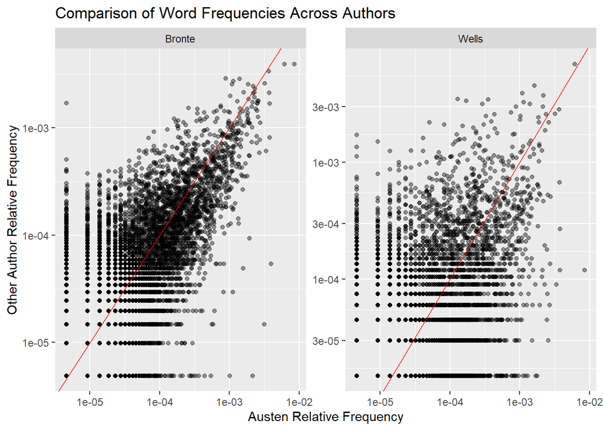

```r
freq_long |>
  ggplot(aes(Austen, other_freq)) +
  geom_point(alpha = 0.4) +
  geom_abline(color = "red") +
  facet_wrap(~other_author, scales = "free") +
  scale_x_log10() +
  scale_y_log10() +
  labs(
    x = "Austen Relative Frequency",
    y = "Other Author Relative Frequency",
    title = "Comparison of Word Frequencies Across Authors"
  )
```

### Why log scales?

- Word frequencies follow Zipf’s law
- Log‑log plots reveal structure more clearly

### **Correlation Tests**

```r
freq_long |>
  group_by(other_author) |>
  summarise(
    correlation = cor(Austen, other_freq, use = "complete.obs"),
    p_value = cor.test(Austen, other_freq)$p.value
  )
```

```
# A tibble: 2 × 3
  other_author correlation   p_value
  <chr>              <dbl>     <dbl>
1 Bronte             0.748 0
2 Wells              0.423 6.07e-259
```

This gives:

- Correlation between Austen and Brontë
- Correlation between Austen and Wells

### **How to Interpret the Plots**

### **1. Points near the red line**

→ Words used at similar rates by both authors.

### **2. Points above the line**

→ Words used more often by Brontë/Wells than Austen.

### **3. Points below the line**

→ Words Austen uses more frequently.

### **4. Tight clustering**

→ Authors have similar vocabularies.

### **5. Wide scatter**

→ Authors differ stylistically.

Typically:

- **Austen vs Brontë** → higher correlation (similar genre, era)
- **Austen vs Wells** → lower correlation (sci‑fi vs Regency romance)

### **You now have a complete, end‑to‑end workflow**

This is a full professional‑grade text‑analysis pipeline:

- Data acquisition
- Cleaning
- Unicode standardization
- Normalization
- Tokenization
- Stop‑word removal
- Frequency analysis
- Reshaping
- Visualization
- Statistical comparison

## Sentiment Analysis — Complete Explanation + All R Code

### Overview — What Sentiment Analysis Is

When humans read text, we naturally infer emotional tone:

- Is the passage **positive** or **negative**?
- Does it express **fear**, **joy**, **anger**, **trust**, **sadness**, etc.?
- Does the author imply emotion indirectly (“showing not saying”)?

**Sentiment Analysis** (aka *opinion mining*) tries to do this computationally.

### Common uses:

- Customer reviews
- Social media monitoring
- Product feedback
- Market intelligence
- Political messaging analysis

### Simplest method: Bag‑of‑Words Sentiment

1. Tokenize text into words
2. Look up each word in a **sentiment lexicon**
3. Add up positive and negative words

#### Limitations of Bag‑of‑Words

- Ignores negation:
  - “not good” → counts as “good” (positive)
- Ignores context
- Positive and negative words cancel out over long text
- Works better on **sentences** or **paragraphs** than entire books

### Sentiment Lexicons

Sentiment lexicons assign emotional labels or scores to words.

#### Why multiple lexicons?

Because:

- Words change meaning over time (**semantic drift**)
- Different domains use words differently
- Some lexicons focus on emotions, others on polarity
- Some are numeric, others categorical

### Lexicons in `{tidytext}`

`{tidytext}` provides access to three major lexicons (via `{textdata}`):

### **1. Bing Liu lexicon (“bing”)**

- Labels each word as **positive** or **negative**
- Good for simple polarity analysis

### **2. AFINN lexicon**

- Assigns integer scores from **–5 to +5**
- Captures intensity
  - “terrible” = –3
  - “excellent” = +5

### **3. NRC lexicon**

- Assigns **10 emotions**:
  - anger
  - anticipation
  - disgust
  - fear
  - joy
  - negative
  - positive
  - sadness
  - surprise
  - trust
- A word may have **multiple sentiments**

### Accessing Sentiments in `{tidytext}`

### Load `{textdata}`

```r
library(textdata)
```

### Explore the built‑in `sentiments` data frame

```r
sentiments |>
  arrange(word) |>
  slice_head(n = 10)
```

```
# A tibble: 10 × 2
   word        sentiment
   <chr>       <chr>
 1 2-faces     negative
 2 abnormal    negative
 3 abolish     negative
 4 abominable  negative
 5 abominably  negative
 6 abominate   negative
 7 abomination negative
 8 abort       negative
 9 aborted     negative
10 aborts      negative
```

### Load each lexicon

```r
get_sentiments("bing") |> slice_sample(n = 10)
```

```
# A tibble: 10 × 2
   word          sentiment
   <chr>         <chr>
 1 heedless      negative
 2 displeased    negative
 3 well-regarded positive
 4 inadequate    negative
 5 suck          negative
 6 scummy        negative
 7 terrorize     negative
 8 hissing       negative
 9 strongest     positive
10 spookily      negative
```

```r
get_sentiments("afinn") |> slice_sample(n = 10)
```

```
# A tibble: 10 × 2
   word       value
   <chr>      <dbl>
 1 enslaves      -2
 2 risks         -2
 3 luck           3
 4 mistakes      -2
 5 complained    -2
 6 reassures      1
 7 tumor         -2
 8 drained       -2
 9 stricken      -2
10 celebrated     3
```

```r
get_sentiments("nrc") |> slice_sample(n = 10)
```

```
# A tibble: 10 × 2
   word           sentiment
   <chr>          <chr>
 1 withdraw       negative
 2 deplore        negative
 3 obstacle       negative
 4 boomerang      anticipation
 5 gift           surprise
 6 procession     sadness
 7 aspiring       joy
 8 cardiomyopathy sadness
 9 unfairness     negative
10 snob           negative
```

### List NRC sentiment categories

```r
unique(get_sentiments("nrc")$sentiment) |> sort()
```

```
 [1] "anger"        "anticipation" "disgust"      "fear"         "joy"
 [6] "negative"     "positive"     "sadness"      "surprise"     "trust"
```

### How many NRC words have multiple sentiments?

```r
get_sentiments("nrc") |>
  group_by(word) |>
  summarize(nums = n()) |>
  filter(nums > 1) |>
  nrow() / nrow(get_sentiments("nrc"))
```

```
[1] 0.2654268
```

### Example of a word with multiple sentiments

```r
get_sentiments("nrc") |>
  filter(word == "feeling")
```

```
# A tibble: 10 × 2
   word    sentiment
   <chr>   <chr>
 1 feeling anger
 2 feeling anticipation
 3 feeling disgust
 4 feeling fear
 5 feeling joy
 6 feeling negative
 7 feeling positive
 8 feeling sadness
 9 feeling surprise
10 feeling trust
```

### Count total NRC entries vs unique words

```r
nrow(get_sentiments("nrc"))
```

```
[1] 13872
```

```r
get_sentiments("nrc") |> select(word) |> unique() |> nrow()
```

```
[1] 6453
```

### **Example: Using NRC “Fear” Words**

We will analyze **fear‑related words** in Jane Austen’s novels.

#### Step 1 — Convert Austen books to tidy text

```r
austen_books() |>
  group_by(book) |>
  mutate(
    linenumber = row_number(),
    chapter = cumsum(str_detect(
      text,
      regex("^chapter [\\divxlc]", ignore_case = TRUE)
    ))
  ) |>
  ungroup() |>
  unnest_tokens(output = word, input = text) ->
tidy_books
```

#### Step 2 — Extract only NRC “fear” words

```r
get_sentiments("nrc") |>
  filter(sentiment == "fear") ->
nrcfear
```

#### Step 3 — Count fear words in *Emma*

```r
tidy_books |>
  filter(book == "Emma") |>
  inner_join(nrcfear, by = "word", relationship = "many-to-many") |>
  count(word, sort = TRUE)
```

```
# A tibble: 364 × 2
   word         n
   <chr>    <int>
 1 doubt       98
 2 ill         72
 3 afraid      65
 4 marry       63
 5 change      61
 6 bad         60
 7 feeling     56
 8 bear        52
 9 creature    39
10 obliging    34
# ℹ 354 more rows
```

#### Step 4 — Count how many words belong to each NRC sentiment

```r
get_sentiments("nrc") |>
  group_by(sentiment) |>
  count()
```

```
# A tibble: 10 × 2
# Groups:   sentiment [10]
   sentiment        n
   <chr>        <int>
 1 anger         1245
 2 anticipation   837
 3 disgust       1056
 4 fear          1474
 5 joy            687
 6 negative      3316
 7 positive      2308
 8 sadness       1187
 9 surprise       532
10 trust         1230
```

### **Exercise: Plot Fear Words per Chapter**

Plot the number of fear words in each chapter for each Jane Austen book.

```r
tidy_books |>
  inner_join(nrcfear, by = "word", relationship = "many-to-many") |>
  group_by(book, chapter) |>
  count() ->
fear_chapter

head(fear_chapter)
```

```
# A tibble: 6 × 3
# Groups:   book, chapter [6]
  book                chapter     n
  <fct>                 <int> <int>
1 Sense & Sensibility       1    21
2 Sense & Sensibility       2    12
3 Sense & Sensibility       3    21
4 Sense & Sensibility       4    27
5 Sense & Sensibility       5    14
6 Sense & Sensibility       6     8
```

You would then plot:

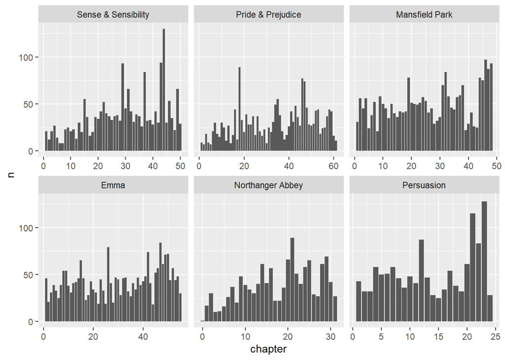

```r
fear_chapter |>
  ggplot(aes(chapter, n)) +
  geom_col() +
  facet_wrap(~book, scales = "free_x")
```

### Positive vs Negative Sentiment in Larger Blocks (An Explanation of the code)

We break text into **blocks of 80 lines** and compute sentiment using **bing**.

#### Step 1 — Join tidy text with bing lexicon

```r
tidy_books |>
  inner_join(get_sentiments("bing"), by = "word",
             relationship = "many-to-many") |>
```

#### Step 2 — Count sentiment words per block

```r
  count(book, index = linenumber %/% 80, sentiment) |>
```

#### Step 3 — Spread positive/negative into columns

```r
  pivot_wider(
    names_from = sentiment, values_from = n,
    values_fill = list(n = 0)
  ) |>
```

#### Step 4 — Compute net sentiment

```r
  mutate(net = positive - negative) ->
janeaustensentiment
```

#### Step 5 — Plot

```r
janeaustensentiment |>
  ggplot(aes(index, net, fill = book)) +
  geom_col(show.legend = FALSE) +
  facet_wrap(~book, ncol = 2, scales = "free_x") +
  scale_fill_viridis_d(end = .9)
```

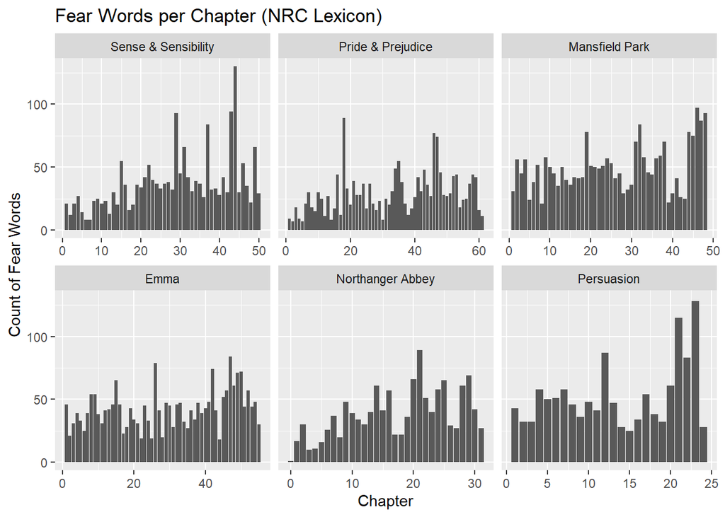

```r
### ---------------------------------------------------------
### PART 1 — FEAR WORDS PER CHAPTER (NRC "fear")
### ---------------------------------------------------------

# Step 1: Extract NRC fear words
nrcfear <- get_sentiments("nrc") |>
  filter(sentiment == "fear")

# Step 2: Join tidy_books with fear lexicon and count per chapter
fear_chapter <- tidy_books |>
  inner_join(nrcfear, by = "word", relationship = "many-to-many") |>
  group_by(book, chapter) |>
  count(name = "fear_count") |>
  ungroup()

# Step 3: Plot fear words per chapter
fear_chapter |>
  ggplot(aes(chapter, fear_count)) +
  geom_col() +
  facet_wrap(~book, scales = "free_x") +
  labs(
    title = "Fear Words per Chapter (NRC Lexicon)",
    x = "Chapter",
    y = "Count of Fear Words"
  )
```

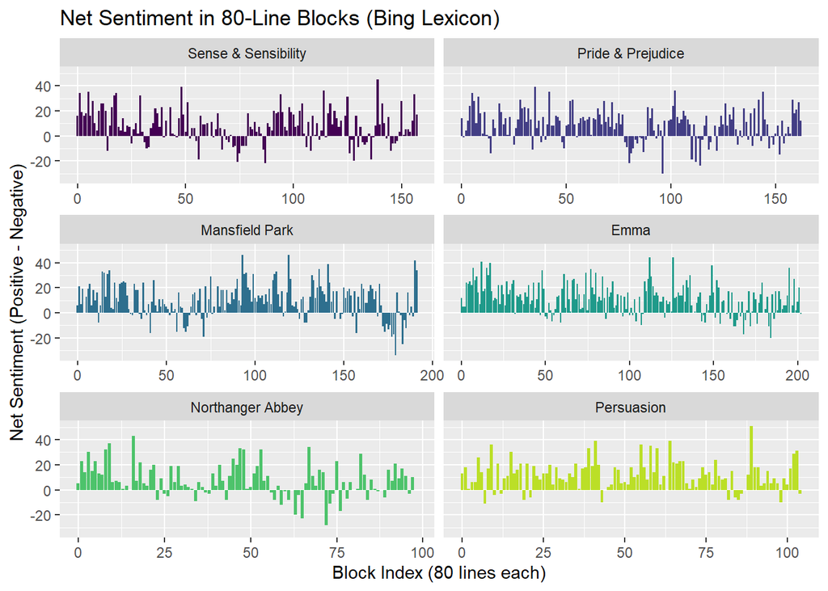

```r
### ---------------------------------------------------------
### PART 2 — POSITIVE vs NEGATIVE SENTIMENT IN 80-LINE BLOCKS
### ---------------------------------------------------------

# Step 1: Join tidy text with bing lexicon
# Step 2: Count sentiment words per 80-line block
# Step 3: Spread positive/negative into columns
# Step 4: Compute net sentiment
janeaustensentiment <- tidy_books |>
  inner_join(get_sentiments("bing"), by = "word",
             relationship = "many-to-many") |>
  count(book, index = linenumber %/% 80, sentiment) |>
  pivot_wider(
    names_from = sentiment,
    values_from = n,
    values_fill = list(n = 0)
  ) |>
  mutate(net = positive - negative)

# Step 5: Plot block-level sentiment
janeaustensentiment |>
  ggplot(aes(index, net, fill = book)) +
  geom_col(show.legend = FALSE) +
  facet_wrap(~book, ncol = 2, scales = "free_x") +
  scale_fill_viridis_d(end = .9) +
  labs(
    title = "Net Sentiment in 80-Line Blocks (Bing Lexicon)",
    x = "Block Index (80 lines each)",
    y = "Net Sentiment (Positive - Negative)"
  )
```

### Adjusting Sentiment Lexicons

Sometimes lexicons misclassify words.

Example:  
In Jane Austen novels, **“miss”** is a *title*, not a negative verb.

#### Step 1 — Count most common sentiment words

```r
tidy_books |>
  inner_join(get_sentiments("bing"), by = "word",
             relationship = "many-to-many") |>
  count(word, sentiment, sort = TRUE) ->
bing_word_counts

bing_word_counts
```

```
# A tibble: 2,585 × 3
   word     sentiment     n
   <chr>    <chr>     <int>
 1 miss     negative   1855
 2 well     positive   1523
 3 good     positive   1380
 4 great    positive    981
 5 like     positive    725
 6 better   positive    639
 7 enough   positive    613
 8 happy    positive    534
 9 love     positive    495
10 pleasure positive    462
# ℹ 2,575 more rows
```

#### Step 2 — Plot top 10 positive/negative words

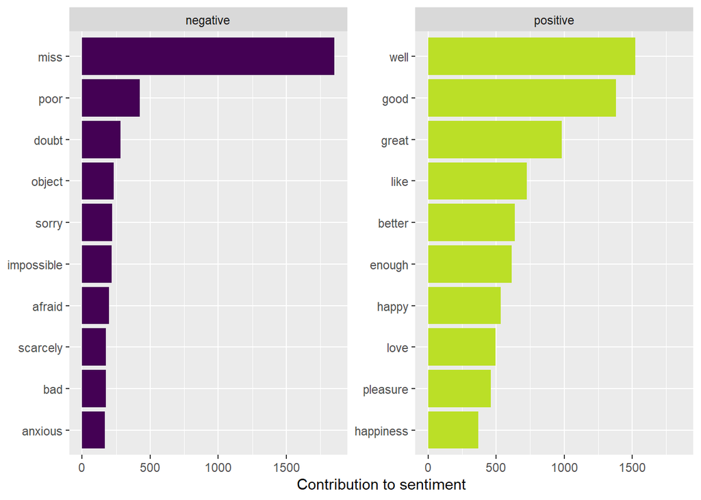

```r
bing_word_counts |>
  group_by(sentiment) |>
  slice_max(order_by = n, n = 10) |>
  ungroup() |>
  mutate(word = fct_reorder(word, n)) |>
  ggplot(aes(word, n, fill = sentiment)) +
  geom_col(show.legend = FALSE) +
  facet_wrap(~sentiment, scales = "free_y") +
  labs(y = "Contribution to sentiment", x = NULL) +
  coord_flip() +
  scale_fill_viridis_d(end = .9)
```

This reveals the problem:  
**“miss” appears as a negative word**, but in Austen it means “young woman.”

## Fixing the Problem

Two approaches:

### **Approach 1 — Add “miss” to stop words**

#### Step 1 — Create custom stop words

```r
custom_stop_words <- bind_rows(
  tibble(word = c("miss"), lexicon = c("custom")),
  stop_words
)
```

#### Step 2 — Rebuild tidy_books without “miss”

```r
austen_books() |>
  group_by(book) |>
  mutate(
    linenumber = row_number(),
    chapter = cumsum(str_detect(
      text,
      regex("^chapter [\\divxlc]", ignore_case = TRUE)
    ))
  ) |>
  ungroup() |>
  unnest_tokens(word, text) |>
  anti_join(custom_stop_words, by = "word") ->
tidy_books_no_miss
```

#### Step 3 — Recompute sentiment counts

```r
tidy_books_no_miss |>
  inner_join(get_sentiments("bing"), by = "word",
             relationship = "many-to-many") |>
  count(word, sentiment, sort = TRUE) ->
bing_word_counts
```

#### Step 4 — Plot again

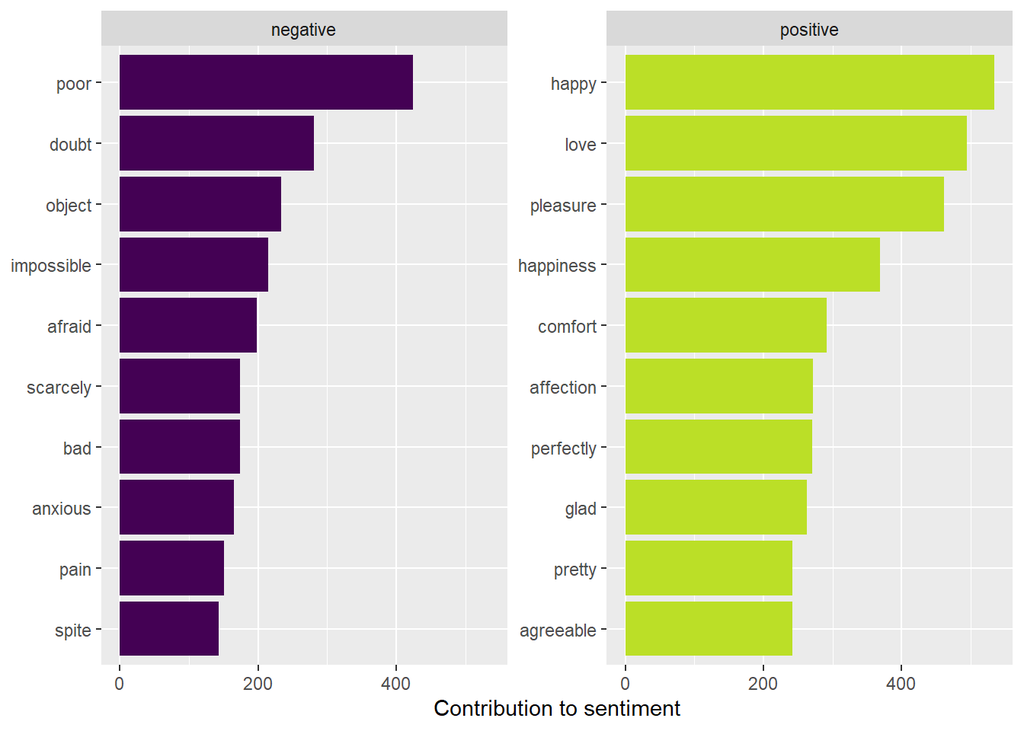

```r
bing_word_counts |>
  group_by(sentiment) |>
  slice_max(order_by = n, n = 10) |>
  ungroup() |>
  mutate(word = fct_reorder(word, n)) |>
  ggplot(aes(word, n, fill = sentiment)) +
  geom_col(show.legend = FALSE) +
  facet_wrap(~sentiment, scales = "free_y") +
  labs(y = "Contribution to sentiment", x = NULL) +
  coord_flip() +
  scale_fill_viridis_d(end = .9)
```

### **Approach 2 — Remove “miss” from the lexicon**

#### Step 1 — Modify bing lexicon

```r
get_sentiments("bing") |>
  filter(word != "miss") ->
bing_no_miss
```

#### Step 2 — Recompute sentiment

```r
tidy_books |>
  inner_join(bing_no_miss, by = "word",
             relationship = "many-to-many") |>
  count(word, sentiment, sort = TRUE) ->
bing_word_counts
```

### **Repeat the Plot by Chapter — Original vs “No Miss”**

We now compare:

- **Original sentiment analysis** using the *bing* lexicon
- **Adjusted sentiment analysis** where the word **“miss”** has been removed from the lexicon

This lets us see how much a single misclassified word can distort sentiment patterns.

We will use `{patchwork}` to place the two plots side‑by‑side.

### Load `{patchwork}`

```r
library(patchwork)
```

### **Build the Original Sentiment Blocks (with “miss” counted as negative)**

```r
## Original
tidy_books |>
  inner_join(get_sentiments("bing"), by = "word",
             relationship = "many-to-many") |>
  count(book, index = linenumber %/% 80, sentiment) |>
  pivot_wider(
    names_from = sentiment, values_from = n,
    values_fill = list(n = 0)
  ) |>
  mutate(net = positive - negative) ->
janeaustensentiment
```

#### What this does:

- Joins tidy text with **bing** lexicon
- Counts positive/negative words in **80‑line blocks**
- Spreads into two columns: `positive`, `negative`
- Computes **net sentiment** = positive − negative

### **Build the Adjusted Sentiment Blocks (with “miss” removed)**

```r
# No Miss
tidy_books |>
  inner_join(bing_no_miss, by = "word",
             relationship = "many-to-many") |>
  count(book, index = linenumber %/% 80, sentiment) |>
  pivot_wider(
    names_from = sentiment, values_from = n,
    values_fill = list(n = 0)
  ) |>
  mutate(net = positive - negative) ->
janeaustensentiment2
```

#### What changed?

- We use `bing_no_miss` instead of `get_sentiments("bing")`
- Everything else is identical

### **Plot 1 — Original**

```r
janeaustensentiment |>
  ggplot(aes(index, net, fill = book)) +
  geom_col(show.legend = FALSE) +
  ggtitle("With Miss as Negative") +
  scale_fill_viridis_d(end = .9) +
  facet_wrap(~book, ncol = 2, scales = "free_x") -> p1
```

### **Plot 2 — Adjusted**

```r
janeaustensentiment2 |>
  ggplot(aes(index, net, fill = book)) +
  geom_col(show.legend = FALSE) +
  ggtitle("Without Miss as Negative") +
  scale_fill_viridis_d(end = .9) +
  facet_wrap(~book, ncol = 2, scales = "free_x") -> p2
```

### **Combine the Plots with `{patchwork}`**

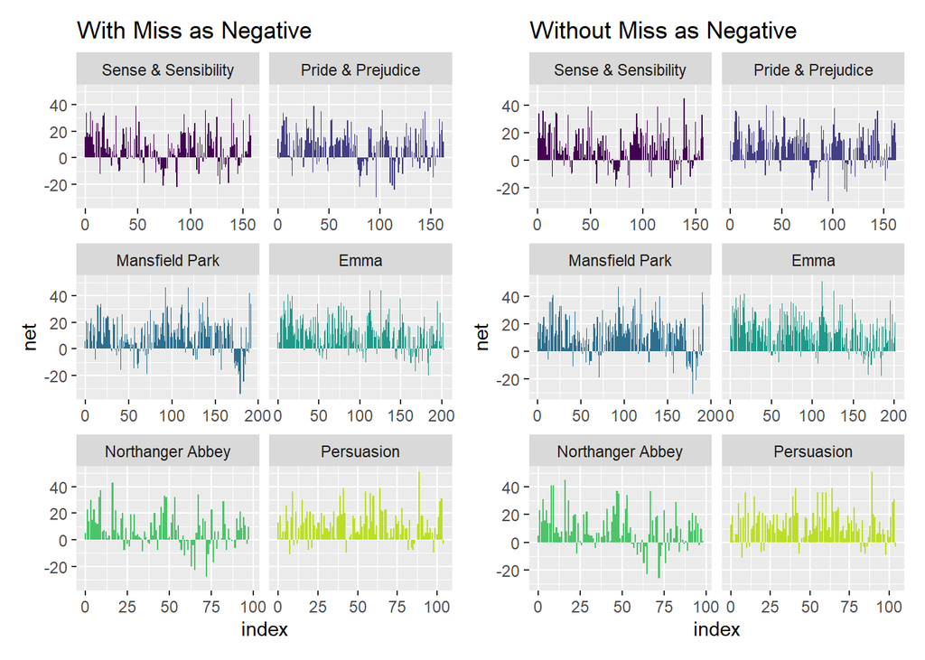

```r
p1 + p2
```

This displays the two sentiment trajectories **side‑by‑side** for direct comparison.

### **Compare the Average Net Sentiment**

```r
janeaustensentiment |>
  summarize(means = mean(net, na.rm = TRUE)) |>
  bind_rows(
    (janeaustensentiment2 |>
      summarize(means = mean(net, na.rm = TRUE))
    )
  )
```

```
# A tibble: 2 × 1
  means
  <dbl>
1  9.71
2 11.7
```

#### Interpretation:

- Removing “miss” makes the overall sentiment **more positive**
- The difference is **about 2 points** on average
- Some blocks (e.g., Emma block 110) change noticeably

This demonstrates how **lexicon errors propagate** into sentiment analysis.

### **Ordering Within Facets — `{tidytext}` Helpers**

When faceting by both **book** and **sentiment**, simple `fct_reorder()` is not enough.  
We need:

- `reorder_within()`
- `scale_x_reordered()`

These allow **independent ordering within each facet**.

### **Rebuild Word Counts Using the Adjusted Lexicon**

```r
tidy_books |>
  inner_join(bing_no_miss, by = "word",
             relationship = "many-to-many") |>
  count(word, sentiment, book, sort = TRUE) ->
bing_word_counts
```

### **Plot Top 5 Words per Book per Sentiment (Naive Version)**

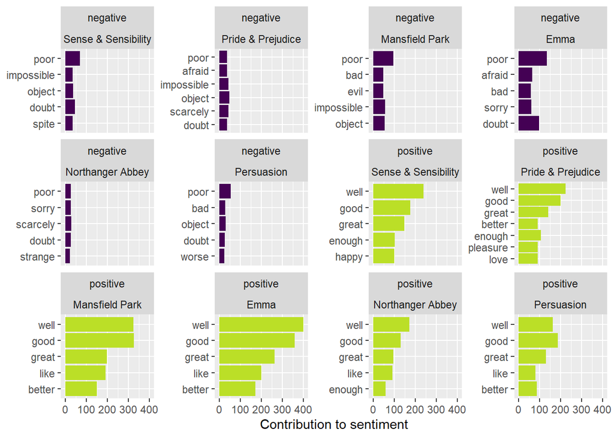

```r
bing_word_counts |>
  group_by(book, sentiment) |>
  slice_max(order_by = n, n = 5) |>
  ungroup() |>
  mutate(word = fct_reorder(parse_factor(word), n)) |>
  ggplot(aes(word, n, fill = sentiment)) +
  geom_col(show.legend = FALSE) +
  facet_wrap(sentiment ~ book, scales = "free_y") +
  labs(
    y = "Contribution to sentiment",
    x = NULL
  ) +
  coord_flip() +
  scale_fill_viridis_d(end = .9)
```

#### Problem:

- Words are ordered **globally**, not within each facet
- Negative words appear compressed because scales are fixed

### **Improved Version Using `reorder_within()`**

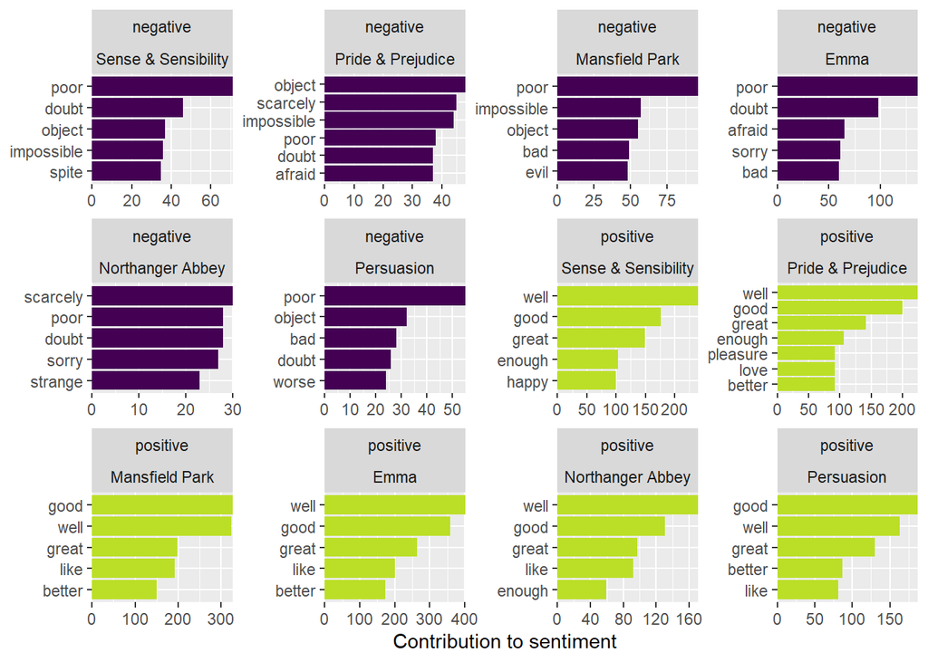

```r
bing_word_counts |>
  group_by(book, sentiment) |>
  slice_max(order_by = n, n = 5) |>
  ungroup() |>
  mutate(word = reorder_within(word, n, book)) |>
  ungroup() |>
  ggplot(aes(word, n, fill = sentiment)) +
  geom_col(show.legend = FALSE) +
  facet_wrap(sentiment ~ book, scales = "free") +
  scale_x_reordered() +
  scale_y_continuous(expand = c(0, 0)) +
  labs(
    y = "Contribution to sentiment",
    x = NULL
  ) +
  coord_flip() +
  scale_fill_viridis_d(end = .9)
```

#### Improvements:

- Each facet has its **own ordering**
- Both axes are **free**, so scales adjust
- Much clearer comparison

### **Sentence‑Level Sentiment Analysis**

We now analyze **Pride and Prejudice** at the **sentence level**.

### **Prepare Sentence Tokens**

```r
tibble(text = prideprejudice) |>
  mutate(
    chapter = cumsum(str_detect(
      text,
      regex("^chapter [\\divxlc]", ignore_case = TRUE)
    )),
    text = str_replace(text, "(Chapter \\d+)", "\\1\\."),
    text = str_replace_all(text, "((Mr)|(Mrs)|(Dr))\\.", "\\1")
  ) |>
  unnest_tokens(sentence, text, token = "sentences") ->
PandP_sentences
```

#### What this does:

- Adds chapter numbers
- Ensures chapter headings end with a period
- Removes periods after “Mr.”, “Mrs.”, “Dr.”
- Tokenizes into **sentences**

### **Compute Sentence‑Level Sentiment**

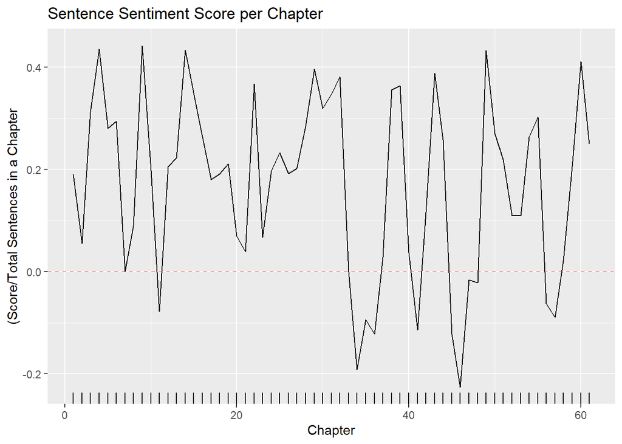

```r
PandP_sentences |>
  mutate(sentence_number = row_number()) |>
  unnest_tokens(word, sentence) |>
  inner_join(get_sentiments("bing"), by = "word",
             relationship = "many-to-many") |>
  filter(chapter > 0) |>
  count(chapter, sentence_number, sentiment) |>
  pivot_wider(
    names_from = sentiment, values_from = n,
    values_fill = list(n = 0)
  ) |>
  mutate(sentence_sent = positive - negative) |>
  mutate(sentence_sent = case_when(
    sentence_sent > 0 ~ 1,
    sentence_sent == 0 ~ 0,
    sentence_sent < 0 ~ -1
  )) |>
  group_by(chapter) |>
  summarize(
    chap_sent_per = sum(sentence_sent) / n(),
    .groups = "keep"
  ) |>
  ggplot(aes(chapter, chap_sent_per)) +
  geom_line() +
  ggtitle("Sentence Sentiment Score per Chapter") +
  ylab("(Score/Total Sentences in a Chapter") +
  xlab("Chapter") +
  geom_hline(yintercept = 0, color = "red", alpha = .4, lty = 2) +
  scale_x_continuous(limits = c(1, 61)) +
  geom_rug(sides = "b")
```

#### Interpretation:

- Shows the **emotional arc** of the novel
- Peaks = positive chapters
- Valleys = negative chapters
- Red line = neutral baseline

## **Chapter‑Level Negative Sentiment Across All Austen Books**

We now find the **most negative chapter** in each book.

### **Prepare Negative Lexicon (Remove “miss”)**

```r
get_sentiments("bing") |>
  filter(sentiment == "negative") |>
  filter(word != "miss") ->
bingnegative
```

### **Count Words per Chapter**

```r
tidy_books |>
  group_by(book, chapter) |>
  summarize(words = n(), .groups = "drop") ->
wordcounts
```

### **Count Negative Words per Chapter**

```r
tidy_books |>
  semi_join(bingnegative, by = "word") |>
  group_by(book, chapter) |>
  summarize(negativewords = n(), .groups = "drop") |>
  left_join(wordcounts, by = c("book", "chapter")) |>
  mutate(ratio = negativewords / words) |>
  filter(chapter != 0) |>
  ungroup() |>
  group_by(book) |>
  slice_max(order_by = ratio) |>
  ungroup()
```

```
# A tibble: 6 × 5
  book                chapter negativewords words  ratio
  <fct>                 <int>         <int> <int>  <dbl>
1 Sense & Sensibility      43           156  3405 0.0458
2 Pride & Prejudice        34           111  2104 0.0528
3 Mansfield Park           46           161  3685 0.0437
4 Emma                     16            81  1894 0.0428
5 Northanger Abbey         21           143  2982 0.0480
6 Persuasion                4            62  1807 0.0343
```

#### Interpretation:

This identifies the **most negative chapter** in each novel.

The results match the narrative:

- **Sense and Sensibility Ch. 43** — Marianne nearly dies
- **Pride and Prejudice Ch. 34** — Darcy’s disastrous first proposal
- **Mansfield Park Ch. 46** — Henry’s adultery scandal
- **Emma Ch. 16** — Emma’s self‑recrimination
- **Northanger Abbey Ch. 21** — Catherine’s Gothic fantasies
- **Persuasion Ch. 4** — Anne’s heartbreak flashback

# **Word Cloud Plots**

Word clouds are one of the most recognizable text‑analysis visualizations.  
They’re fun, fast, and visually appealing — but they’re also **statistically weak**.

Still, they’re worth understanding because:

- They’re widely used in business and media
- They’re easy to generate
- They’re useful for **exploratory** analysis

Let’s walk through everything step‑by‑step.

### Load `{wordcloud}`

```r
library(wordcloud)
```

### **Basic Word Cloud (with stop words removed)**

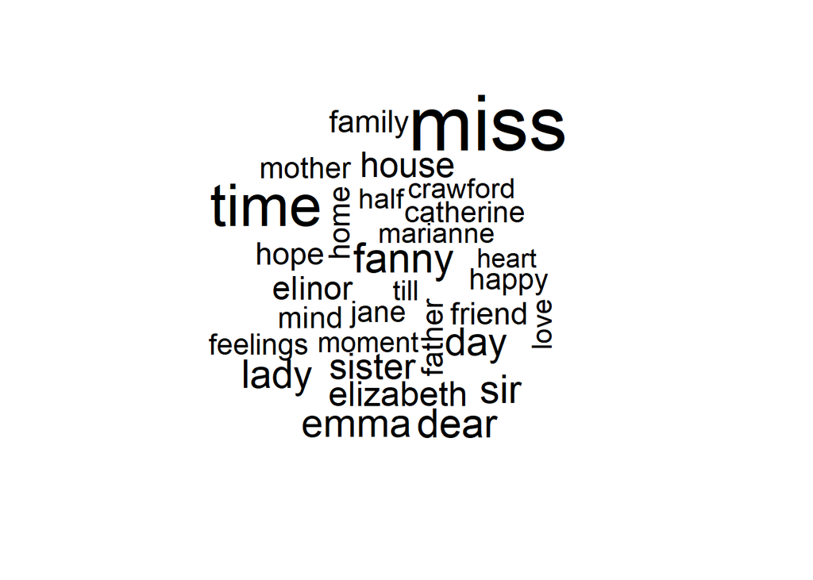

```r
tidy_books |>
  anti_join(stop_words, by = "word") |>
  count(word) |>
  with(wordcloud(word, n, max.words = 30))
```

#### What this does:

1. Removes stop words
2. Counts remaining words
3. Passes `word` and `n` to `wordcloud()`
4. Displays the **top 30 words** by frequency

### **Word Cloud with Custom Stop Words (removing “miss”)**

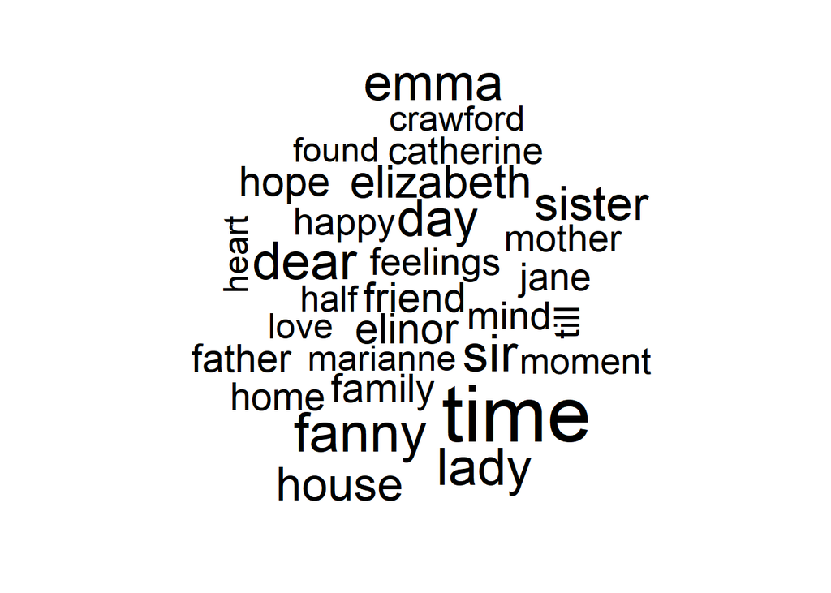

```r
## Custom stop words - no miss
tidy_books |>
  anti_join(custom_stop_words, by = "word") |>
  count(word) |>
  with(wordcloud(word, n, max.words = 30))
```

#### Why this matters:

- “miss” is extremely common in Austen
- But it’s a **title**, not a negative verb
- Removing it gives a more meaningful cloud

### **Limitations of Word Clouds**

Word clouds are **not** good for:

- Comparing frequencies
- Showing precise values
- Comparing across books or authors
- Statistical analysis

They:

- Lack a common axis
- Emphasize visual impression over accuracy
- Hide differences in scale

Better alternatives include:

- Sorted bar charts
- Faceted bar charts
- Heatmaps
- Scatterplots
- Network plots

[ChatterPlot](https://paulvanderlaken.com/2018/11/21/chatterplots/)

### **Alternative Visualization: Top 50 Words by Sentiment and Book**

This uses `{ggrepel}` to avoid overlapping labels.

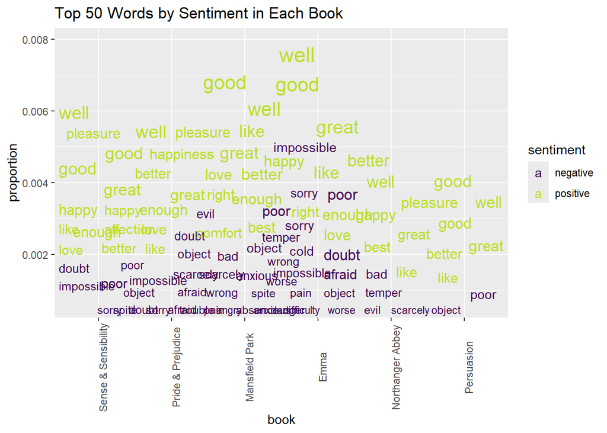

```r
library(ggrepel)

tidy_books |>
  inner_join(bing_no_miss, by = "word",
             relationship = "many-to-many") |>
  count(book, word, sentiment, sort = TRUE) |>
  mutate(proportion = n / sum(n)) |>
  group_by(sentiment) |>
  slice_max(order_by = n, n = 50) |>
  ungroup() ->
tempp

tempp |>
  ggplot(aes(book, proportion, label = word)) +
  geom_text_repel(
    segment.alpha = 0,
    aes(
      color = sentiment, size = proportion
    ),
    max.overlaps = 50
  ) +
  scale_size_continuous(range = c(3, 6), guide = "none") +
  theme(axis.text.x = element_text(angle = 90)) +
  ggtitle("Top 50 Words by Sentiment in Each Book") +
  scale_color_viridis_d(end = .9)
```

#### Why this is better than a word cloud:

- Words are placed meaningfully
- Size encodes proportion
- Color encodes sentiment
- Books appear on the x‑axis
- Labels repel each other

This is a **true analytical visualization**, not just decorative.

### **Heatmaps — A More Powerful Alternative**

Heatmaps allow:

- Direct comparison across books
- A shared color scale
- Clear patterns of usage
- Easy identification of distinctive words

We’ll build two heatmaps:

1. **Global top shared words**
2. **Top shared words within each book**

### **Step 1 — Count non‑stop words by book**

```r
word_counts <- tidy_books |>
  anti_join(stop_words, by = "word") |>
  count(book, word)
```

### **Step 2 — Keep only words appearing in ≥ 3 books**

```r
shared_words <- word_counts |>
  group_by(word) |>
  summarize(n_books = n_distinct(book), .groups = "drop") |>
  filter(n_books >= 3)
```

### **Step 3 — Select top shared words overall**

```r
top_words <- word_counts |>
  semi_join(shared_words, by = "word") |>
  group_by(word) |>
  summarize(total = sum(n), .groups = "drop") |>
  slice_max(order_by = total, n = 20) |>
  pull(word)
```

### **Step 4 — Heatmap of Global Top Words**

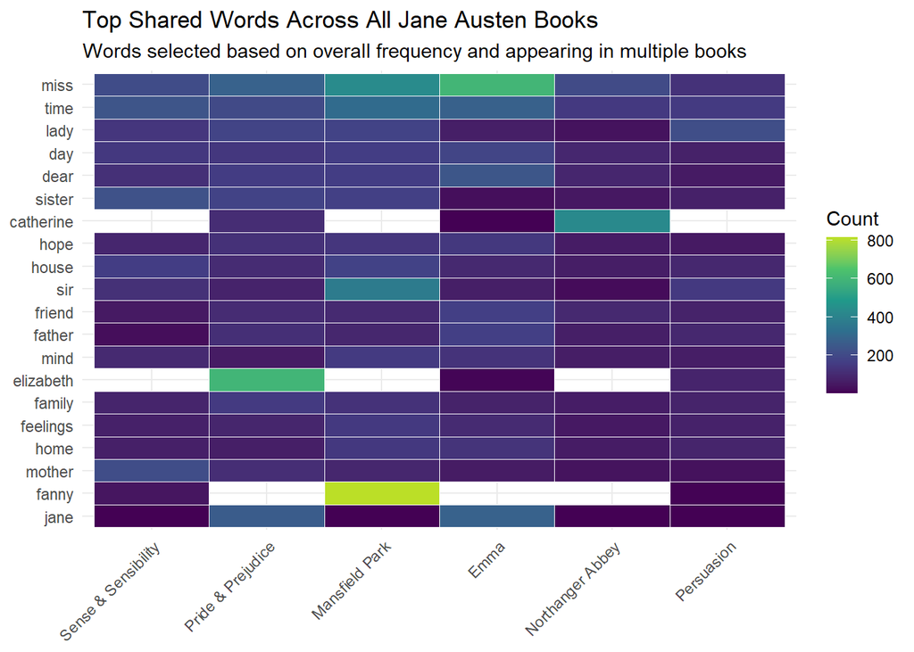

```r
word_counts |>
  filter(word %in% top_words) |>
  ggplot(aes(x = book, y = fct_reorder(word, n), fill = n)) +
  geom_tile(color = "white") +
  scale_fill_viridis_c(end = .9) +
  labs(
    title = "Top Shared Words Across All Jane Austen Books",
    subtitle = "Words selected based on overall frequency and appearing in multiple books",
    x = NULL,
    y = NULL,
    fill = "Count"
  ) +
  theme_minimal() +
  theme(axis.text.x = element_text(angle = 45, hjust = 1))
```

#### Interpretation:

- Shows which words dominate across the entire corpus
- Uses a **common color scale**
- Easy to compare across books

### **Step 5 — Top Shared Words Within Each Book**

```r
top_shared_words <- word_counts |>
  semi_join(shared_words, by = "word") |>
  group_by(book) |>
  slice_max(order_by = n, n = 20) |>
  ungroup()
```

### **Step 6 — Heatmap of Within‑Book Top Words**

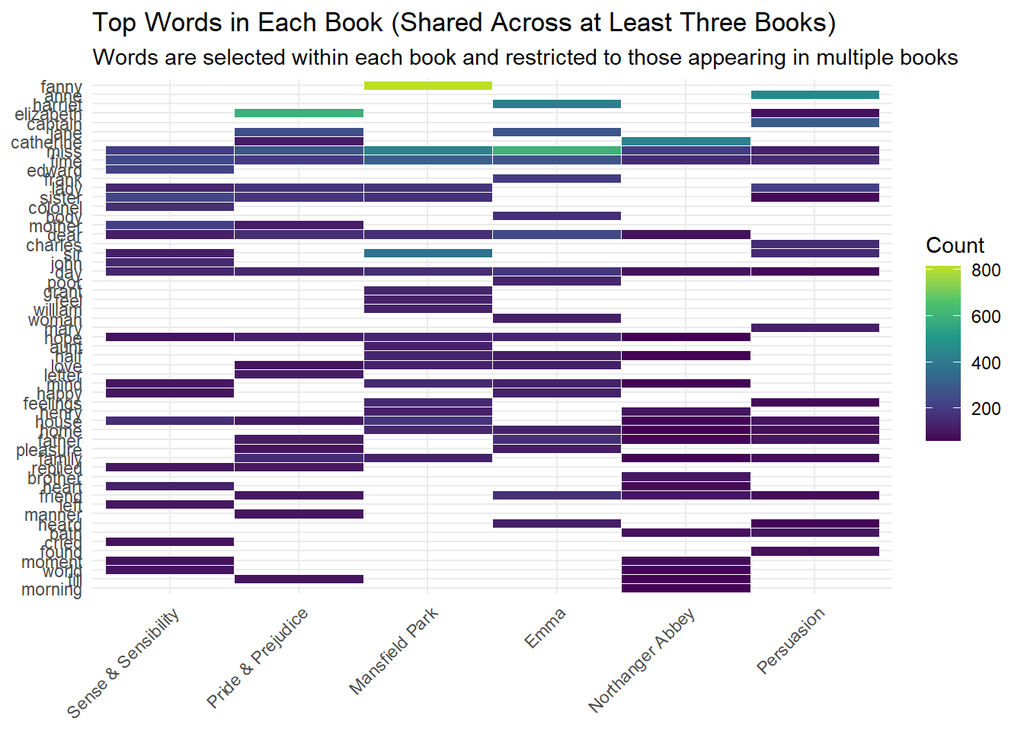

```r
top_shared_words |>
  ggplot(aes(x = book, y = fct_reorder(word, n), fill = n)) +
  geom_tile(color = "white") +
  scale_fill_viridis_c(end = .9) +
  labs(
    title = "Top Words in Each Book (Shared Across at Least Three Books)",
    subtitle = "Words are selected within each book and restricted to those appearing in multiple books",
    x = NULL,
    y = NULL,
    fill = "Count"
  ) +
  theme_minimal() +
  theme(axis.text.x = element_text(angle = 45, hjust = 1))
```

### **How to Interpret the Two Heatmaps**

##### **Heatmap 1 — Global Top Words**

- Selects words based on **overall frequency**
- Shows how those words vary across books
- Good for **corpus‑level comparison**

##### **Heatmap 2 — Within‑Book Top Words**

- Selects top words **within each book**
- A word may appear in ≥3 books but only be top‑20 in some
- Good for **book‑specific patterns**

### **Final Thoughts on Word Clouds vs Alternatives**

#### Word clouds:

- Fun
- Quick
- Good for presentations
- Bad for analysis

#### Better tools:

- Bar charts
- Faceted comparisons
- Heatmaps
- Scatterplots
- Network diagrams

These give **real insight**, not just visual flair.